# Water Quality at Yarra River (Chandler Hwy), 1991-1994 vs 2021-2024

Author

Ting-Ting, Wu

Published

December 8, 2025

## 🛠️ Exercises

### Library

```r
library(readxl)
library(tidyverse)
library(visdat)
library(scales)
library(nullabor)
library(kableExtra)
library(knitr)
library(plotly)
library(GGally)
```

## Question 1. Conduct an IDA

### Read and check the data

**Step 1. Read the data**

```r
suppressWarnings(
  yarra_wq_raw <- read_excel("data/yarra_wq.xls")
)
```

**Step 2. Check variable types**

```r
glimpse(yarra_wq_raw)
```

```
Rows: 16,383
Columns: 10
$ `Site ID`             <dbl> 229108, 229108, 229108, 2291…
$ Name                  <chr> "YARRA DS MCMAHONS", "YARRA …
$ Datetime              <dttm> 1962-06-15 00:00:00, 1962-0…
$ `Data Type`           <chr> "Quantity", "Quantity", "Qua…
$ `Parameter ID`        <dbl> 142, 142, 142, 142, 142, 142…
$ Parameter             <chr> "Streamflow (mean daily)", "…
$ Value                 <dbl> 80, 84, 95, 227, 223, 136, 2…
$ `Unit of Measurement` <chr> "ML/day", "ML/day", "ML/day"…
$ Quality               <dbl> 1, 1, 1, 1, 1, 1, 1, 1, 1, 1…
$ Resolution            <chr> "Raw Data", "Raw Data", "Raw…
```

**Step 3. Check the missing values**

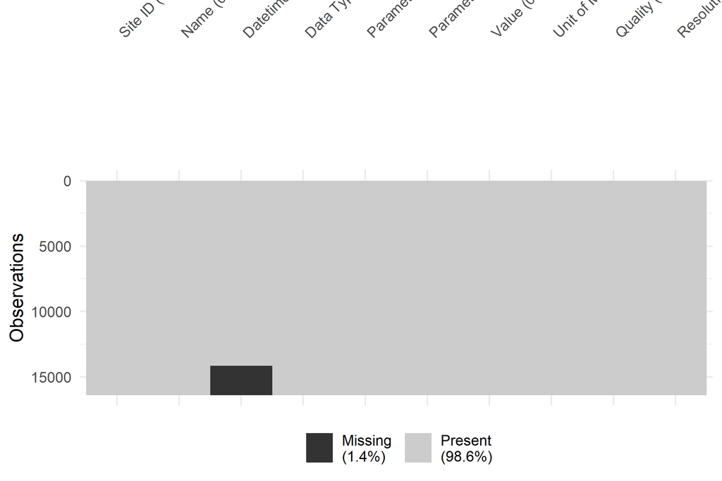

```r
vis_miss(yarra_wq_raw)
```

Table 1 shows the number of rows and missing Datetime values for each site. Only Site 229200 has missing Datetime values (all 2,271 rows), while the other sites have complete records. After checking the dataset from Excel, we found that the Datetime values for Site 229200 appear missing because they are stored in a different format compared to the other sites. This issue needs to be corrected to ensure consistency and enable proper analysis in the following steps.

```r
yarra_wq_raw %>%
  group_by(`Site ID`) %>%
  summarise(
    `Count` = n(),
    `Missing datetime` = sum(is.na(Datetime)),
    .groups = "drop"
  ) %>%
  arrange(desc(`Missing datetime`)) %>%
  kable(align = "l")
```

Table 1: Number of rows and missing Datetime values by Site ID

| Site ID | Count | Missing datetime |
| --- | --- | --- |
| 229200 | 2271 | 2271 |
| 229108 | 6573 | 0 |
| 229142 | 1947 | 0 |
| 229143 | 3509 | 0 |
| 229147 | 2083 | 0 |

**Step 4. Check for Unique Identifiers**

Table 2 shows the number of rows for each `Site ID` and its corresponding site name. Each site has a unique pairing between `Site ID` and `Name`, confirming they can be treated as consistent identifiers.

```r
yarra_wq_raw %>%
  group_by(`Site ID`, Name) %>%
  summarise(`Count` = n(), .groups = "drop") %>%
  arrange(`Site ID`) %>%
  kable(align = "l")
```

Table 2: Number of rows for each Site ID and Name

| Site ID | Name | Count |
| --- | --- | --- |
| 229108 | YARRA DS MCMAHONS | 6573 |
| 229142 | YARRA @ TEMPLESTOWE | 1947 |
| 229143 | YARRA @ CHANDLER HWY | 3509 |
| 229147 | YARRA @ YERING GORGE | 2083 |
| 229200 | YARRA @ WARRANDYTE | 2271 |

**Step 5. Fix the Datetime issue**

```r
# Read the data into two separate tables
yarra_wq_part1 <- read_excel("data/yarra_wq.xls", range = cell_rows(1:14113))

yarra_wq_part2 <- read_excel("data/yarra_wq.xls",
                             range = cell_rows(14114:16384),
                             col_names = names(yarra_wq_part1))

# Convert the time format
yarra_wq_part2 <- yarra_wq_part2 %>%
  mutate(Datetime = ymd_hms(Datetime))

# Merge the datasets
yarra_wq_dt_fixed <- bind_rows(yarra_wq_part1, yarra_wq_part2)
```

**Step 6. Convert variables to the correct types**

```r
yarra_wq_ida <- yarra_wq_dt_fixed %>%
  mutate(
    `Site ID` = as.character(`Site ID`),
    `Parameter ID` = as.character(`Parameter ID`),
    Quality = as.character(Quality),
    Value = as.numeric(Value)
  )
```

**Step 7. Convert dates**  
To make IDA easier, split `Datetime` into `date`, `year`, `month` and `time` first.

```r
yarra_wq_ida <- yarra_wq_ida %>%
  mutate(date = date(Datetime),
         year = year(Datetime),
         month = month(Datetime, label = TRUE, abbr = FALSE),
         hour = hour(Datetime)
  )
```

### Understand and clean the data

#### 1. Explanation for Data Type

Table 3 shows the monitoring periods by site and data type. The majority of the dataset consists of Quantity (streamflow) records collected across five sites between 1891 and 1982. In contrast, Quality (water chemistry) records are available only at Site 229143 (Yarra @ Chandler Hwy), spanning from 1991 to 1994 and resuming from 2020 to 2025.  
This distinction is crucial: *while streamflow data are extensive, answering the question “Has water quality declined from the 1990s to recent years?”* relies solely on the Quality series from Site 229143.

```r
yarra_wq_ida %>%
  group_by(`Site ID`, Name, `Data Type`) %>%
  summarise(
    Start = min(date, na.rm = TRUE),
    End = max(date, na.rm = TRUE),
    Records = n(),
    .groups = "drop"
  ) %>%
  arrange(`Data Type`, `Site ID`) %>%
  kable(align = "l")
```

Table 3: Monitoring periods by Site ID, Name, and Data Type (Quantity vs Quality).

| Site ID | Name | Data Type | Start | End | Records |
| --- | --- | --- | --- | --- | --- |
| 229143 | YARRA @ CHANDLER HWY | Quality | 1991-01-08 | 2025-03-26 | 1619 |
| 229108 | YARRA DS MCMAHONS | Quantity | 1962-06-15 | 1982-01-01 | 6573 |
| 229142 | YARRA @ TEMPLESTOWE | Quantity | 1975-09-24 | 1982-01-01 | 1947 |
| 229143 | YARRA @ CHANDLER HWY | Quantity | 1975-09-27 | 1982-01-01 | 1890 |
| 229147 | YARRA @ YERING GORGE | Quantity | 1974-07-27 | 1982-01-02 | 2083 |
| 229200 | YARRA @ WARRANDYTE | Quantity | 1891-01-02 | 1898-04-02 | 2271 |

Clean the data to include only records with `Data Type` = “Quality”.

```r
yarra_wq_quality <- yarra_wq_ida %>%
  filter(`Data Type` == "Quality")
```

#### 2. Explanation for Parameters

Table 4 summarises the number of records for each water quality parameter at Site 229143. The patterns in record counts are consistent with the monitoring framework described in the [DEECA - Water quality parameters](https://data.water.vic.gov.au/water-quality-parameters) documentation.

- pH, Water Temperature, Salinity as EC@25, and Turbidity
  - Dominate the dataset with 221–225 observations each, forming the core of the monitoring program. These align with the key parameters listed by the Victorian Government as routinely measured in the field through continuous monitoring and spot measurements.
- Nutrients (e.g., Nitrogen as Total, Phosphorus as TRP) and heavy metals (e.g., Arsenic, Cadmium, Chromium, Copper, Nickel, Zinc)
  - Have ~50 observations each. This reflects laboratory-based analysis of samples, which is typically conducted monthly or less frequently.
- Some physical and nutrient measures (e.g., TSS, Colour, Total Kjeldahl Nitrogen, Total Phosphorus)
  - Have only 30–35 observations, suggesting they were included in specific monitoring suites rather than part of the core program.
- Nitrogen as Nitrate [2331] and Nitrogen as Ammonia [2335]
  - Are extremely sparse, with only 2 records each, and are not suitable for meaningful trend analysis.

```r
yarra_wq_quality %>%
  group_by(`Parameter ID`, Parameter) %>%
  summarise(Count = n(), .groups = "drop") %>%
  arrange(desc(Count)) %>%
  DT::datatable()
```

Table 4: Number of records for each water quality parameter

|  | Parameter ID | Parameter | Count |
| --- | --- | --- | --- |
| 1 | 210 | pH | 225 |
| 2 | 450 | Water Temperature | 225 |
| 3 | 820 | Salinity as EC@25 | 225 |
| 4 | 810 | Turbidity | 221 |
| 5 | 2332 | Nitrogen as Nitrite (NO3) | 53 |
| 6 | 2337 | Nitrogen as Total | 53 |
| 7 | 2364 | Phosphorus as TRP | 53 |
| 8 | 2521 | Total Arsenic | 53 |
| 9 | 2571 | Total Cadmium | 53 |
| 10 | 2601 | Total Chromium | 53 |

[output cut: 12 more lines]

#### 3. Explanation for Quality

`Quality` codes have specific meanings provided by the [DEECA - What do quality codes mean?](https://data.water.vic.gov.au/what-do-quality-codes-mean).

```r
quality_codes_meanings <- tribble(
  ~`Quality Code`, ~Meaning,
  2,  "Good quality data – minimal editing required (±0–10 mm drift correction)",
  65, "Data supplied by other authorities; validation not supplied",
  180, "Data not recorded – equipment malfunction"
)

quality_codes_meanings %>%
  kable(align = "l")
```

Table 5: Quality codes and their meanings

| Quality Code | Meaning |
| --- | --- |
| 2 | Good quality data – minimal editing required (±0–10 mm drift correction) |
| 65 | Data supplied by other authorities; validation not supplied |
| 180 | Data not recorded – equipment malfunction |

Table 6 shows the distribution of Quality codes restricted to water quality records. Most of these are coded as 2 (“Good quality data”), with a smaller proportion coded as 65 (“Other authorities, validation not supplied”). A very small number are coded as 180 (“Not recorded – equipment malfunction”).

```r
yarra_wq_quality %>%
  count(Quality, sort = TRUE, name = "Count") %>%

  # Add a new column showing the percentage of each code
  # formatted as %
  mutate(Percentage = percent(Count / nrow(yarra_wq_quality),
                                      accuracy = 0.01)) %>%
  kable(align = "l")
```

Table 6: Frequency of Quality codes in the dataset

| Quality | Count | Percentage |
| --- | --- | --- |
| 2 | 1197 | 73.93% |
| 65 | 412 | 25.45% |
| 180 | 10 | 0.62% |

Figure 1 shows the distribution of Quality codes over time. The plot highlights a large temporal gap between the 1994 and 2020, suggesting no quality data were collected (or retained) during this period. In addition, the Quality codes are clearly segregated by era:

- Early 1990s records are dominated by code 65 (data supplied by other authorities, validation not supplied), with small proportions of code 180.
- Recent 2020–2025 records are exclusively code 2 (good quality data).  
  This strong temporal separation reinforces the need to carefully compare the two eras, as both the data availability and the coding standards differ substantially.

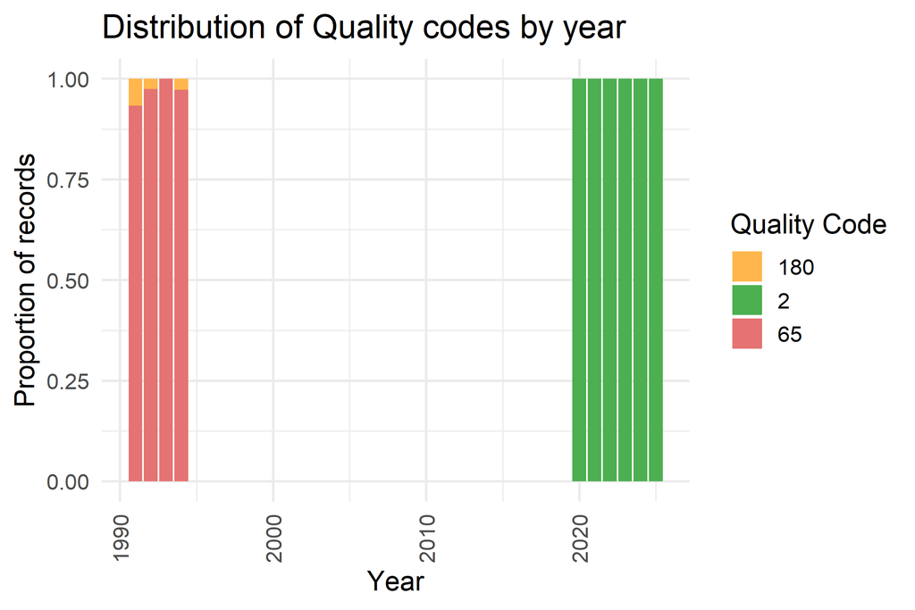

Figure 1

```r
yarra_wq_quality %>%
  count(year, Quality) %>%
  ggplot(aes(x = year, y = n, fill = factor(Quality))) +
  geom_col(position = "fill") +
  scale_fill_manual(values = c("2" = "#4CAF50", "65" = "#E57373", "180" = "#FFB74D")) +
  labs(
    x = "Year",
    y = "Proportion of records",
    fill = "Quality Code",
    title = "Distribution of Quality codes by year"
  ) +
  theme_minimal(base_size = 13) +
  theme(axis.text.x = element_text(angle = 90, vjust = 0.5))
```

#### 4. Explanation for Frequency

Figure 2 shows the yearly coverage of water quality parameters, where each point indicates that a parameter was recorded in a given year.  
The Quality parameters show a clear monitoring pattern. 11 parameters between 1991 and 1994, and 17 parameters between 2020 and 2025.  
Only four parameters: **Water Temperature (450), Turbidity (810), Salinity as EC@25 (820), and pH (210)** were consistently monitored in both the early and recent periods. These are the only parameters that provide a valid basis for assessing whether water quality has declined from the 1990s to recent years.

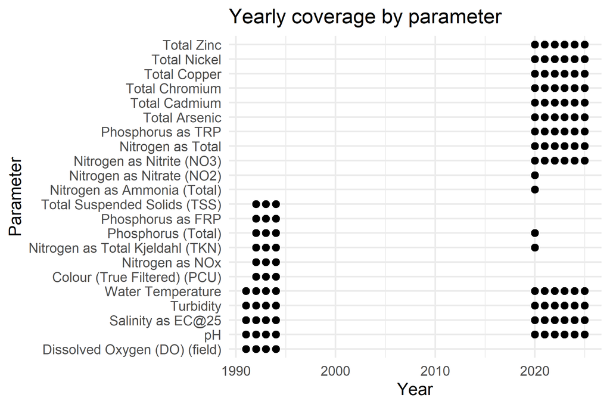

Figure 2

```r
coverage <- yarra_wq_quality %>%

  # Keep only distinct combinations of Parameter and year
  distinct(Parameter, year) %>%

  # For each Parameter, find the earliest year it was recorded
  group_by(Parameter) %>%
  mutate(first_year = min(year, na.rm = TRUE)) %>%
  ungroup() %>%

  # Reorder parameters on the y-axis by their first year of appearance
  mutate(Parameter = fct_reorder(Parameter, first_year))

# Plot
ggplot(coverage, aes(x = year, y = Parameter)) +
  geom_point(size = 2) +
  labs(x = "Year", y = "Parameter", title = "Yearly coverage by parameter") +
  scale_x_continuous(breaks = pretty_breaks()) +
  theme_minimal(base_size = 12)
```

Figure 3 shows the number of sampling days per month for the four core parameters-pH (210), Water Temperature (450), Turbidity (810), and Salinity as EC@25 (820). According to [Water quality parameters](https://data.water.vic.gov.au/water-quality-parameters), water quality monitoring is typically carried out monthly, consistent with the standard approach of collecting samples and returning them to the laboratory for analysis.  
From 1991-1994, sampling is very regular, with exactly one observation per month.  
In contrast, the recent period (2020-2025) shows greater variability. Some months have multiple records (e.g., September 2020 with eight sampling days), while others have only one or no records at all.  
This indicates that although more parameters are now measured overall, the sampling frequency of the four core parameters is inconsistent in recent years. The missing months reduce comparability across time, and only 2024 provides a complete set of monthly observations, making it the only recent year directly comparable to the consistent early 1990s records.

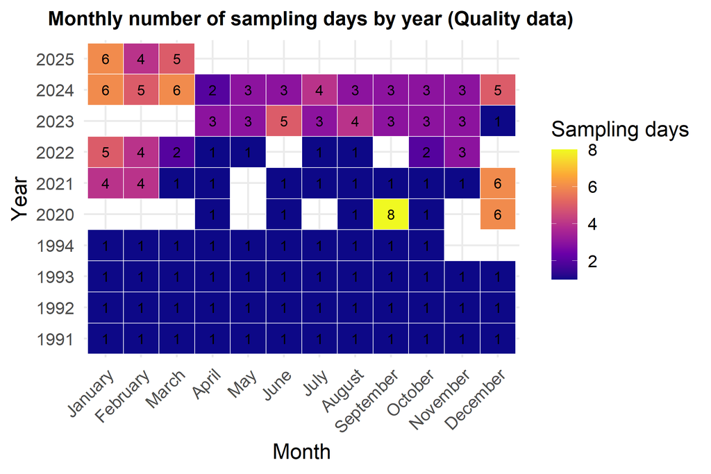

Figure 3

```r
core_params <- c("210", "450", "810", "820")

yarra_wq_quality %>%

  # Keep only the four core parameters
  filter(`Parameter ID` %in% core_params) %>%
  group_by(year, month) %>%
  summarise(n_days = n_distinct(date), .groups = "drop") %>%

  # Create a heatmap of sampling days by year and month
  ggplot(aes(x = month, y = factor(year), fill = n_days)) +

  # heatmap tiles
  geom_tile(color = "white") +

  # overlay counts
  geom_text(aes(label = n_days), color = "black", size = 3) +

  # Better visibility
  scale_fill_viridis_c(option = "C", name = "Sampling days") +
  labs(
    x = "Month",
    y = "Year",
    title = "Monthly number of sampling days by year (Quality data)"
  ) +
  theme_minimal(base_size = 13) +
  theme(axis.text.x = element_text(angle = 45, hjust = 1),
        plot.title = element_text(face = "bold", hjust = 0.4, size = 12))
```

Table 7 counted days where the same parameter had the same value recorded more than once. It reports the number of such days and their share of all observed days.  
Across the retained years, there were 29 days with duplicate records out of 195 observed days (14.9%).

```r
yarra_wq_quality %>%

  # For each record, count how many times the same occurs
  add_count(date, `Parameter ID`, Value, name = "n_same") %>%
  summarise(

    # Count distinct dates where at least one duplicate record exists
    `Days with duplicates` = n_distinct(date[n_same > 1]),

    # Count total number of distinct sampling dates
    `Total days` = n_distinct(date),

    # Calculate the share of duplicate days as a percentage
    `Share` = percent(`Days with duplicates`/`Total days`, accuracy = 0.1)
  ) %>%
  kable(align = "l")
```

Table 7

| Days with duplicates | Total days | Share |
| --- | --- | --- |
| 29 | 195 | 14.9% |

#### 5. Exploration of Values

*Are there any implausible values in the water-quality data-Water Temperature (450), Turbidity (810), Salinity as EC@25 (820), and pH (210)?*  
According to [The Water Unit Project - Yarra River Report](https://thewaterunitproject.wordpress.com/yarra-river-report/) and [DEECA - What do water quality parameters mean?](https://data.water.vic.gov.au/what-do-water-quality-parameters-mean):

- pH (210): Mid range is best values drifting away from neutral ~7 (≈6.5-8.5 band) indicate increasing acidity/alkalinity stress.
- Water temperature (450): Seasonal in Victoria (≈4 °C winter to ≥25 °C summer), warmer water generally lowers dissolved oxygen.
- Turbidity (810): Lower is clearer, spikes are common during storms-use a log scale and flag very high events rather than drop them.
- Salinity / EC@25 (820): Proxy for dissolved salts (µS/cm). Freshwater < 1,000 µS/cm, higher often indicates brackish/estuarine influence or dry season concentration.

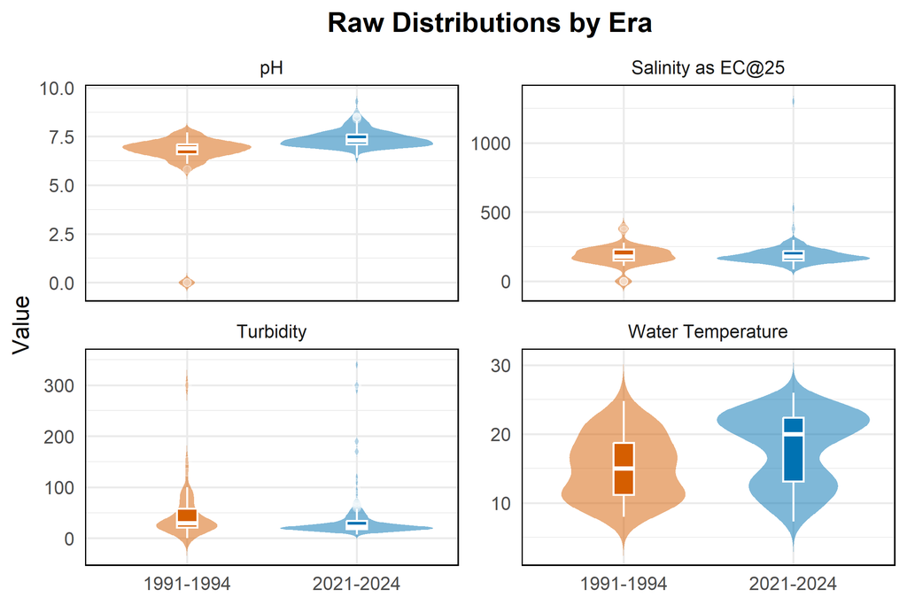

Figure 4: Initial violin plots showing the raw distributions

```r
yarra_wq_quality %>%

  # Keep only the four core parameters
  filter(`Parameter ID` %in% core_params) %>%
  mutate(

    # Create an era variable: 1991-1994 vs 2021-2024
    era = if_else(year <= 1994, "1991-1994", "2021-2024")) %>%

  # Plot
  ggplot(aes(x = era, y = Value, fill = era)) +
    geom_violin(trim = FALSE, alpha = 0.5, color = NA) +
    geom_boxplot(width = 0.12, outlier.alpha = 0.25, color = "white") +
    facet_wrap(~ Parameter, scales = "free_y") +
    labs(title = "Raw Distributions by Era",
         x = NULL, y = "Value") +
    theme_minimal() +
    theme(legend.position = "none",
          plot.title = element_text(face = "bold", hjust = 0.5),
          panel.border = element_rect(fill = NA, linewidth = 0.6))
```

After examining the raw data, Figure 4 identified several issues.

- Quality = 180 affects both pH and salinity (EC) measurements.
- For salinity in 2021-2024, there is an extreme outlier.
- Turbidity shows many outliers without clear documentation, so we will apply a log transformation for IDA.  
  I reviewed the month’s data: the other two EC readings are within the normal range. Although values near 1,000 µS/cm can occur (brackish/estuarine influence or dry-season concentration), the extreme outlier would skew the analysis, so we exclude it and proceed with the remaining two observations.

```r
salinity_aug2024 <- yarra_wq_quality %>%
  filter(`Parameter ID` == 820,
         year == 2024,
         month == "August") %>%
  select(Name, `Parameter ID`, Parameter, Value, Quality, date)

kable(salinity_aug2024,
      caption = "Salinity (EC@25, ID 820) records for August 2024")
```

Salinity (EC@25, ID 820) records for August 2024

| Name | Parameter ID | Parameter | Value | Quality | date |
| --- | --- | --- | --- | --- | --- |
| YARRA @ CHANDLER HWY | 820 | Salinity as EC@25 | 230 | 2 | 2024-08-13 |
| YARRA @ CHANDLER HWY | 820 | Salinity as EC@25 | 1300 | 2 | 2024-08-19 |
| YARRA @ CHANDLER HWY | 820 | Salinity as EC@25 | 220 | 2 | 2024-08-28 |

Cleaned distributions:

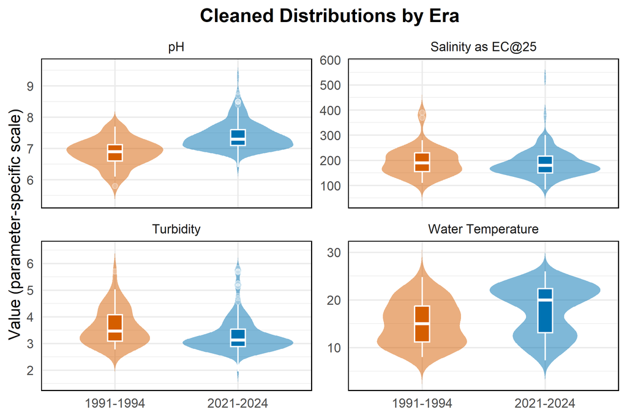

Figure 5

```r
yarra_wq_quality %>%

  # Keep only the four core parameters and drop records with code 180
  filter(`Parameter ID` %in% core_params,
         Quality != 180) %>%

  # For salinity, drop the extreme outliers that would distort plots
  filter(!(`Parameter ID` == 820 & Value > 1000)) %>%
  mutate(
    era = if_else(year <= 1994, "1991-1994", "2021-2024"),
    Value_plot = case_when(

      # Apply log transformation to turbidity only
      `Parameter ID` == 810 ~ log(Value),
      TRUE ~ Value)) %>%

# Plot
ggplot(aes(x = era, y = Value_plot, fill = era)) +
  geom_violin(trim = FALSE, alpha = 0.5, color = NA) +
  geom_boxplot(width = 0.12, outlier.alpha = 0.25, color = "white") +
  facet_wrap(~ Parameter, scales = "free_y") +
  labs(title = "Cleaned Distributions by Era",
       x = NULL, y = "Value (parameter-specific scale)") +
  theme_minimal() +
  theme(legend.position = "none",
        plot.title = element_text(face = "bold", hjust = 0.5),
        panel.border = element_rect(fill = NA, linewidth = 0.6))
```

#### 6. Exploration of hour

Figure Figure 6 shows that the data were collected during daytime hours (07:00-15:00), with most samples concentrated around 10 to 11 a.m. There are five observations recorded at hour 0, which appear anomalous. However, as these cases are few and unlikely to affect the overall results.

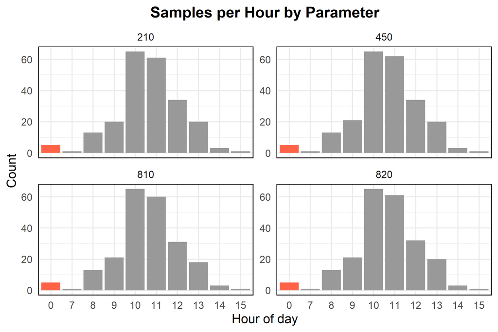

Figure 6

```r
yarra_wq_quality %>%
  filter(`Parameter ID` %in% core_params,
         Quality != 180) %>%

  # Convert hour into an ordered factor so bars show in correct order
  mutate(hour = factor(hour, levels = 0:23, ordered = TRUE)) %>%

  # Count how many samples exist for each parameter-hour combination
  count(`Parameter ID`, hour, name = "n") %>%

  # Plot
  ggplot(aes(x = hour, y = n, fill = hour == "0")) +
  geom_col() +
  facet_wrap(~ `Parameter ID`, scales = "free_y") +
  scale_fill_manual(values = c("TRUE" = "tomato", "FALSE" = "grey60"), guide = "none") +
  labs(title = "Samples per Hour by Parameter", x = "Hour of day", y = "Count") +
  theme_minimal() +
  theme(plot.title = element_text(face = "bold", hjust = 0.5),
        panel.border = element_rect(fill = NA, linewidth = 0.6))
```

### Clean the data

```r
yarra_wq_clean <- yarra_wq_quality %>%

  # Drop records with Quality codes 180 (data not recorded)
  filter(!Quality == 180) %>%

  # Keep only the four core parameters consistently measured
  filter(`Parameter ID` %in% core_params) %>%

  # More than 6 months missing in 2020 and 2025
  filter(!year %in% c(2020, 2025)) %>%

  # Remove exact duplicate rows
  distinct(date, Value, `Parameter ID`, .keep_all = TRUE) %>%

  filter(!(`Parameter ID` == "820" & Value > 1000)) %>%

  # Retain only variables relevant for analysis and reporting
  select(`Parameter ID`, Parameter, Value, year, month, date)
```

Write out a cleaned data set

```r
write.csv(yarra_wq_clean, "data/yarra_wq_clean.csv", row.names = FALSE)
```

### Analysis design

For descriptive pattern comparisons, we present the **four available years from the 1990s (1991-1994) and the 2020s (2021-2024)** to show context and variability.

## Question 2. EDA

### Dataset for analysis

```r
yarra_wq_analysis <- yarra_wq_clean %>%
  mutate(

    # era label
    era = if_else(year <= 1994, "1991-1994", "2021-2024"),

    # index of the year within the era
    era_year_idx = if_else(era == "1991-1994", year - 1990L, year - 2020L),

    # Y1, Y2, Y3, Y4 label
    year_num = factor(paste0("Y", era_year_idx),
               levels = paste0("Y", 1:4), ordered = TRUE),

    # Short name
    param_short = case_when(
      `Parameter ID` == 210 ~ "pH",
      `Parameter ID` == 450 ~ "Temperature",
      `Parameter ID` == 810 ~ "Turbidity",
      `Parameter ID` == 820 ~ "Salinity"),

    # sequential month within each era
    month_num = as.integer(month),
    seq_month = (era_year_idx - 1L) * 12L + month_num)

# calculate monthly mean for better analysis
monthly_means <- yarra_wq_analysis %>%
  group_by(param_short, `Parameter ID`, era, year_num, month_num) %>%
  summarise(month_mean = mean(Value, na.rm = TRUE), .groups = "drop")
```

### Distributions of Values

Figure 7 shows observations across 1990s and 2020s. Outliers (red) are flagged by Tukey’s 1.5×IQR rule computed within each Parameter × Month group.

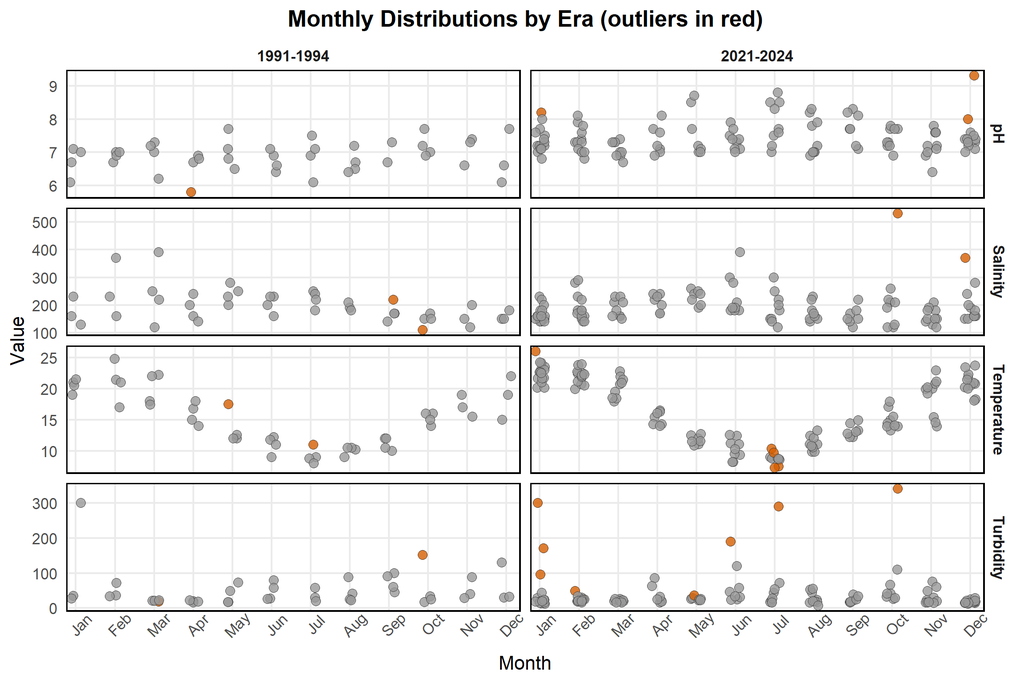

Figure 7

```r
df_monthly <- yarra_wq_analysis %>%
  group_by(era, param_short, month_num) %>%

  # For each group, calculate Tukey’s fences for outlier detection
  mutate(
    q1  = quantile(Value, 0.25, na.rm = TRUE),
    q3  = quantile(Value, 0.75, na.rm = TRUE),
    iqr = q3 - q1,
    lo  = q1 - 1.5 * iqr,
    hi  = q3 + 1.5 * iqr,
    is_outlier = Value < lo | Value > hi
  ) %>%
  ungroup()

# Plot
ggplot(df_monthly, aes(x = month_num, y = Value, color = is_outlier)) +

  # Jittered points to show individual observations
  geom_jitter(aes(fill = is_outlier),
              shape = 21, color = "grey20", stroke = 0.25,
              width = 0.15, height = 0, alpha = 0.8, size = 1.8) +

  # orange fill = outliers, grey = not outliers
  scale_fill_manual(values = c(`TRUE` = "#D55E00", `FALSE` = "grey60"),
                    guide = "none") +
  facet_grid(param_short ~ era, scales = "free_y") +
  scale_x_continuous(breaks = 1:12, labels = month.abb,
                     expand = expansion(mult = c(0.01, 0.02))) +
  labs(
    title = "Monthly Distributions by Era (outliers in red)",
    x = "Month", y = "Value"
  ) +
  theme_minimal(base_size = 8) +
  theme(
    axis.text.x = element_text(angle = 45),
    panel.grid.minor = element_blank(),
    strip.text = element_text(face = "bold"),
    plot.title   = element_text(face = "bold", hjust = 0.5),
    panel.border = element_rect(fill = NA, linewidth = 0.6))
```

Figure Figure 8 shows monthly means for each year (Y1-Y4) within each era. Turbidity and EC are plotted on a log scale to dampen spikes, pH and Temperature remain on their original scales.

- Water Temperature: The 2020s curves are smoother, likely reflecting greater sampling density.
- pH: Monthly means cluster around neutrality in both eras, with the 2020s higher on average.
- Salinity (EC, log): Mid seasonality, a modest mid winter dip with occasional spring spikes in the 2020s. Overall levels are broadly comparable across eras after removing brackish outliers.
- Turbidity (log): No stable annual cycle, variability is event driven (storm/runoff) with sporadic peaks. The log scale improves readability but does not reveal a strong seasonal pattern.

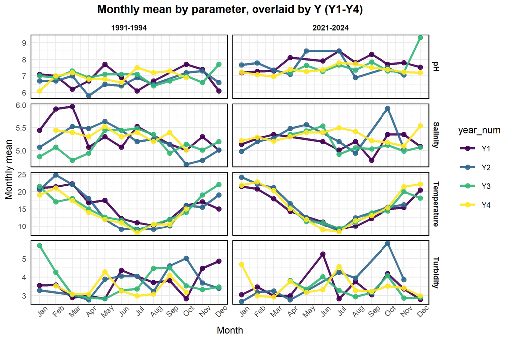

Figure 8

```r
monthly_means_log <- monthly_means %>%

  # For turbidity and salinity, log transform the monthly mean
  mutate(
    month_mean_log = case_when(
      `Parameter ID` %in% c(810, 820) ~ log(month_mean),
      TRUE ~ month_mean))

# Plot
ggplot(monthly_means_log,
       aes(x = month_num, y = month_mean_log, color = year_num)) +
  geom_line(linewidth = 0.9, alpha = 0.9) +
  geom_point(size = 1.8, alpha = 0.9) +

  # X-axis = months
  scale_x_continuous(breaks = 1:12, labels = month.abb) +
  facet_grid(param_short ~ era, scales = "free_y") +
  labs(
    title = "Monthly mean by parameter, overlaid by Y (Y1-Y4)",
    x = "Month", y = "Monthly mean"
  ) +
  theme_minimal(base_size = 8) +
  theme(
    axis.text.x = element_text(angle = 45),
    plot.title   = element_text(face = "bold", hjust = 0.5),
    strip.text = element_text(face = "bold"),
    panel.border = element_rect(fill = NA, linewidth = 0.6))
```

### Exploration into pH

```r
ph_monthly_means <- monthly_means %>%
  filter(param_short == "pH")
```

#### Distribution of pH

No strong seasonality in pH is evident in the raw data, so summarising by monthly means is a sensible way to compare eras.

Figure Figure 9 shows histograms of monthly mean pH for the two eras. The shaded band marks 6.8-8.0, the dashed lines are the band limits, and the solid line marks pH = 7 (neutral).

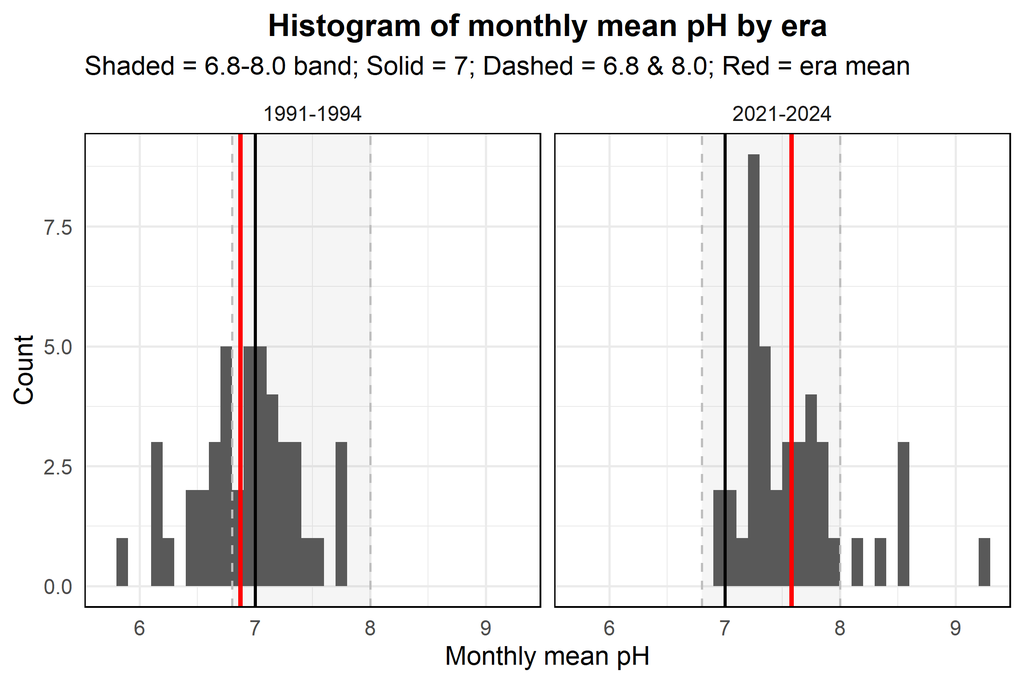

Figure 9

```r
mean_ph_by_era <- ph_monthly_means %>%

  # For each era, calculate the mean of monthly mean pH
  group_by(era) %>%
  summarise(mean_pH = mean(month_mean, na.rm = TRUE), .groups = "drop")

ggplot(ph_monthly_means, aes(x = month_mean)) +

  # Add a shaded band for the good pH range 6.8-8.0
  annotate("rect", xmin = 6.8, xmax = 8.0, ymin = -Inf, ymax = Inf, alpha = 0.06) +

  # Histogram of monthly mean pH values
  geom_histogram(binwidth = 0.1, boundary = 0, closed = "left") +

  # Add a vertical line at neutral pH = 7
  geom_vline(xintercept = 7, linetype = "solid", linewidth = 0.7, color = "black") +

  # Add dashed lines at the band limits
  geom_vline(xintercept = c(6.8, 8.0), linetype = "dashed", color = "grey") +

  # Add vertical red lines for the mean pH of each era
  geom_vline(data = mean_ph_by_era, aes(xintercept = mean_pH),
             color = "red", linewidth = 0.9) +
  facet_wrap(~ era) +
  labs(title = "Histogram of monthly mean pH by era",
       x = "Monthly mean pH", y = "Count",
       subtitle = "Shaded = 6.8-8.0 band; Solid = 7; Dashed = 6.8 & 8.0; Red = era mean") +
  theme_minimal() +
  theme(
    panel.border = element_rect(fill = NA, linewidth = 0.6),
    plot.title = element_text(face = "bold", hjust = 0.5)
    )
```

#### Era Summary of pH Monthly Means

```r
# Summarise distribution statistics of monthly mean pH by era
ph_era_summary <- ph_monthly_means %>%
  select(era, month_mean) %>%
  group_by(era) %>%
  summarise(
    n = n(),
    min = min(month_mean, na.rm = TRUE),
    q1 = quantile(month_mean, 0.25, na.rm = TRUE),
    med = median(month_mean, na.rm = TRUE),
    q3 = quantile(month_mean, 0.75, na.rm = TRUE),
    max = max(month_mean, na.rm = TRUE),
    mu = mean(month_mean, na.rm = TRUE),
    sd = sd(month_mean,   na.rm = TRUE),
    se = sd / sqrt(n),
    t95 = qt(0.975, df = n - 1),
    ci_low = mu - t95 * se,
    ci_high = mu + t95 * se,
    .groups = "drop"
  ) %>%

  # Create nicely formatted summary columns
  mutate(
    Range = sprintf("%.2f-%.2f", min, max),
    `Median (Q1, Q3)` = sprintf("%.2f<br>(%.2f, %.2f)", med, q1, q3),
    `95% CI for μ` = sprintf("%.2f-%.2f", ci_low, ci_high)
  ) %>%
  select(
    era, n, Range, min, q1, med, q3, max,
    mu, sd, se, `95% CI for μ`, `Median (Q1, Q3)`
  )

kable(ph_era_summary,
      caption = "pH Monthly Means - Era Summary")
```

Table 8: pH Monthly Means - Era Summary

| era | n | Range | min | q1 | med | q3 | max | mu | sd | se | 95% CI for μ | Median (Q1, Q3) |
| --- | --- | --- | --- | --- | --- | --- | --- | --- | --- | --- | --- | --- |
| 1991-1994 | 44 | 5.80-7.70 | 5.8 | 6.6 | 6.9 | 7.1 | 7.7 | 6.9 | 0.44 | 0.07 | 6.74-7.01 | 6.90 (6.60, 7.12) |
| 2021-2024 | 41 | 6.90-9.30 | 6.9 | 7.2 | 7.4 | 7.8 | 9.3 | 7.6 | 0.49 | 0.08 | 7.42-7.73 | 7.40 (7.23, 7.78) |

Figure Figure 10. To highlight the shift in centre and spread, the figure overlays Normal curves for monthly mean pH by era. Solid lines mark the era means (μ), dashed lines mark μ ± 1 SD, and the shaded bands show the same.  
1991-1994: μ = 6.87, μ ± 1 SD = ~6.4-7.3 (SD = 0.44).  
2021-2024: μ = 7.58, μ ± 1 SD = ~7.0-8.1 (SD = 0.49).

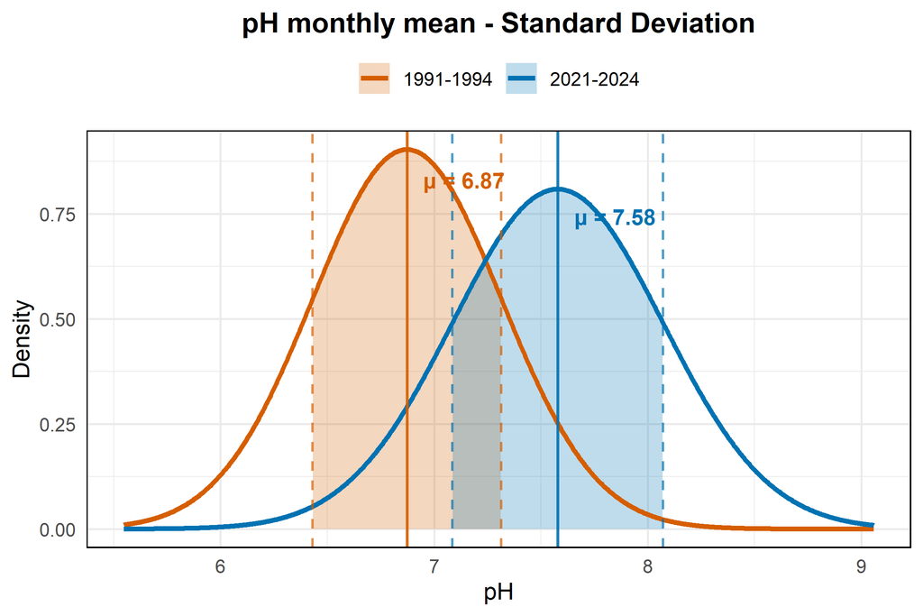

Figure 10

```r
# For each era, calculate mean and standard deviation of monthly mean pH
ph_stats <- ph_monthly_means %>%
  group_by(era) %>%
  summarise(mu = mean(month_mean, na.rm = TRUE),
            sd = sd(month_mean,   na.rm = TRUE),
            .groups = "drop")

# Define a grid of x values covering ±3 SD from the observed means
x_min <- min(ph_stats$mu - 3*ph_stats$sd)
x_max <- max(ph_stats$mu + 3*ph_stats$sd)
grid  <- seq(x_min, x_max, length.out = 1000)

# For each era, create a normal distribution curve using mu and sd
ph_norm_df <- ph_stats %>%
  rowwise() %>%
  mutate(curve = list(tibble(
    x = grid,
    y = dnorm(grid, mean = mu, sd = sd),
    in_1sd = abs(grid - mu) <= sd
  ))) %>%
  unnest(curve)

# Prepare labels for plotting mean values
ph_stats_lab <- ph_stats %>%
  mutate(

    # y position for text label
    y_lab = dnorm(mu, mean = mu, sd = sd) * 0.92,

    # text to display (mean)
    label = sprintf("μ = %.2f", mu)
  )

# Plot
ggplot(ph_norm_df, aes(x = x, y = y, color = era)) +

  # Shade the ±1 SD interval under each curve
  geom_ribbon(
    data = subset(ph_norm_df, in_1sd),
    aes(x = x, ymin = 0, ymax = y, fill = era),
    alpha = 0.25, color = NA, inherit.aes = FALSE
  ) +
  geom_line(linewidth = 1.1) +

  # Add vertical lines for the mean and ±1 SD
  geom_vline(data = ph_stats, aes(xintercept = mu,  color = era),
             linetype = "solid",  linewidth = 0.7, alpha = 0.9, show.legend = FALSE) +
  geom_vline(data = ph_stats, aes(xintercept = mu - sd, color = era),
             linetype = "dashed", linewidth = 0.6, alpha = 0.7, show.legend = FALSE) +
  geom_vline(data = ph_stats, aes(xintercept = mu + sd, color = era),
             linetype = "dashed", linewidth = 0.6, alpha = 0.7, show.legend = FALSE) +

  # Add text labels for the mean values
  geom_text(data = ph_stats_lab,
            aes(x = mu, y = y_lab, label = label, color = era),
            hjust = -0.2, fontface = "bold", size = 3.6, show.legend = FALSE) +
  labs(
    title = "pH monthly mean - Standard Deviation",
    x = "pH", y = "Density", color = NULL, fill = NULL
  ) +
  theme_minimal(base_size = 11) +
  theme(
    legend.position = "top",
    panel.border = element_rect(fill = NA, linewidth = 0.6),
    plot.title = element_text(face = "bold", hjust = 0.5)
  )
```

Comparing monthly mean pH between eras shows a consistent upward shift. The summary statistics (Figure 11) indicate that the mean pH increased by ~0.71 units, with similar gains in the median (+0.50), lower quartile (+0.63), and upper quartile (+0.65). The standard deviation also rose slightly (+0.05).  
Figure 12 shows the distribution of month-by-month pH differences between eras, defined as Δ = (2021-2024) − (1991-1994). The histogram is mostly > 0 with a mode around 0.4-0.6 pH and a long right tail (up to ~2.4), indicating that **monthly mean pH in the 2020s is typically higher (more alkaline) than in the 1990s, with only a few months near zero or negative**.

```r
ph_summary_diff <- ph_era_summary %>%
  select(era, n, min, q1, med, q3, max, mu, sd, se) %>%

  # Make one row, with separate columns for each era
  pivot_wider(
    names_from = era,
    values_from = c(n, min, q1, med, q3, max, mu, sd, se)
  ) %>%

  # Compute differences: 2021-2024 minus 1991-1994
  mutate(
    `Δ n` = `n_2021-2024` - `n_1991-1994`,
    `Δ min` = `min_2021-2024` - `min_1991-1994`,
    `Δ Q1` = `q1_2021-2024` - `q1_1991-1994`,
    `Δ Median` = `med_2021-2024` - `med_1991-1994`,
    `Δ Q3` = `q3_2021-2024` - `q3_1991-1994`,
    `Δ max` = `max_2021-2024` - `max_1991-1994`,
    `Δ μ` = `mu_2021-2024` - `mu_1991-1994`,
    `Δ SD` = `sd_2021-2024` - `sd_1991-1994`,
    `Δ SE`     = `se_2021-2024` - `se_1991-1994`
  ) %>%

  # Keep only the difference columns we want in the table
  transmute(
    `Δ μ`, `Δ Median`, `Δ Q1`, `Δ Q3`,
    `Δ min`, `Δ max`, `Δ SD`, `Δ SE`
  ) %>%

  # Round all values to 2 decimal places
  mutate(across(everything(), ~ round(.x, 2)))


kable(
  ph_summary_diff,
  caption = "Differences in pH Monthly Means (2021-2024 minus 1991-1994)"
)
```

| Δ μ | Δ Median | Δ Q1 | Δ Q3 | Δ min | Δ max | Δ SD | Δ SE |
| --- | --- | --- | --- | --- | --- | --- | --- |
| 0.71 | 0.5 | 0.63 | 0.65 | 1.1 | 1.6 | 0.05 | 0.01 |

Figure 11: Differences in pH Monthly Means (2021-2024 minus 1991-1994)

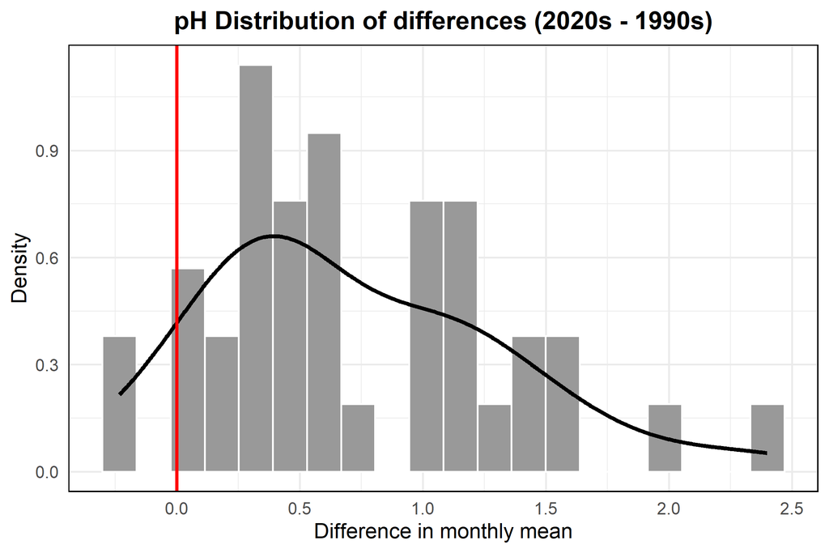

Figure 12

```r
ph_monthly_means_diff <- ph_monthly_means %>%

  # Reshape so each era is in its own column
  pivot_wider(names_from = era, values_from = month_mean) %>%

  # Calculate the difference in monthly mean pH between eras
  mutate(diff = `2021-2024` - `1991-1994`)

# Plot
ggplot(ph_monthly_means_diff, aes(x = diff)) +
  geom_histogram(aes(y = after_stat(density)),
                 bins = 20, color = "white", fill = "grey60") +
  geom_density(linewidth = 1, adjust = 1.1, na.rm = TRUE) +

  # Vertical reference line at zero (no difference)
  geom_vline(xintercept = 0, color = "red", linewidth = 0.8) +
  labs(
    title = "pH Distribution of differences (2020s - 1990s)",
    x = "Difference in monthly mean",
    y = "Density"
  ) +
  theme_minimal() +
  theme(
    panel.border = element_rect(fill = NA, linewidth = 0.6),
    plot.title = element_text(face = "bold", hjust = 0.5)
    )
```

### Exploration into Water Temperature

```r
temp_monthly_means <- monthly_means %>%
  filter(param_short == "Temperature") %>%

  mutate(

    # Create a new season variable
    season = case_when(
      month_num %in% c(12, 1, 2) ~ "Summer",
      month_num %in% c(3, 4, 5) ~ "Autumn",
      month_num %in% c(6, 7, 8)  ~ "Winter",
      month_num %in% c(9, 10, 11)  ~ "Spring"
    ),

    # Make season an ordered factor so plots and summaries follow the natural order
    season = factor(season, levels = c("Summer","Autumn","Winter","Spring"), ordered = TRUE))
```

#### Distribution of Water Temperature

Figure 13 shows the monthly water temperature climatology by era with interquartile ranges. The two eras are nearly indistinguishable in March, July, and October.

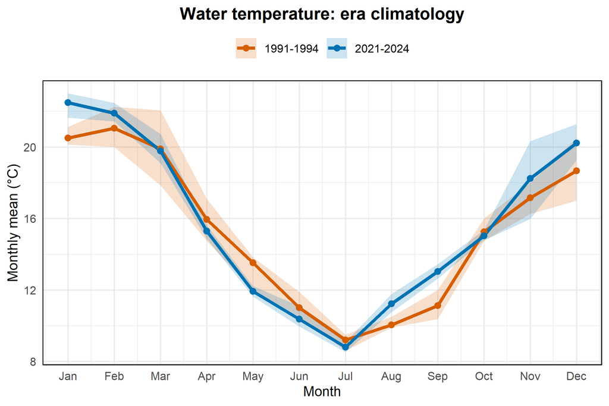

Figure 13

```r
temp_clim_diff <- temp_monthly_means %>%
  group_by(era, month_num, season) %>%
  summarise(
    mu = mean(month_mean, na.rm = TRUE),  # mean monthly temperature
    q1 = quantile(month_mean, 0.25, na.rm = TRUE), # lower quartile
    q3 = quantile(month_mean, 0.75, na.rm = TRUE), # upper quartile
    .groups = "drop")

# Plot
ggplot(temp_clim_diff, aes(x = month_num, y = mu, color = era, fill = era)) +

  # Shaded band for interquartile range
  geom_ribbon(aes(ymin = q1, ymax = q3), alpha = 0.20, color = NA) +
  geom_line(linewidth = 1.1) +
  geom_point(size = 1.8) +

  # Show months on x axis with abbreviations
  scale_x_continuous(breaks = 1:12, labels = month.abb) +
  labs(title = "Water temperature: era climatology",
       x = "Month", y = "Monthly mean (°C)", color = NULL, fill = NULL) +
  theme_minimal(base_size = 10) +
  theme(panel.border = element_rect(fill = NA, linewidth = 0.6),
        legend.position = "top",
        plot.title = element_text(face = "bold", hjust = 0.5))
```

Figure 14 (months grouped by season) shows a clear seasonal pattern. Summer (Dec-Feb) exhibits consistent warming, with the strongest anomalies in Jan (~+2 °C). Autumn (Mar-May) shows uniform cooling, deepest in May. Winter (Jun-Aug) is mixed cooler in Jun-Jul but warmer in Aug-and Spring (Sep-Nov) is generally warmer except October, which is near zero.  
Overall, warming dominates in Summer and Spring, while Autumn cools across all months.

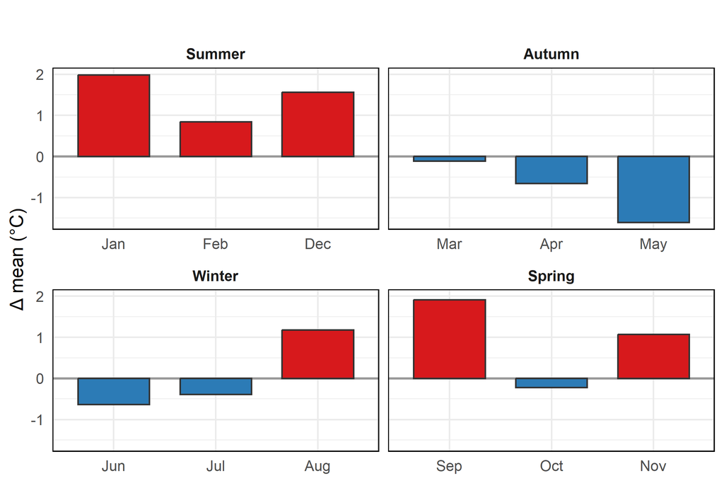

Figure 14

```r
temp_bar_diff_season <- temp_clim_diff %>%

  # Turn month numbers into ordered factor with labels
  mutate(month = factor(month_num, levels = 1:12, labels = month.abb)) %>%
  select(era, season, month_num, month, mu) %>%

  # Reshape so each era has its own column
  pivot_wider(names_from = era, values_from = mu) %>%

  # Calculate the difference in mean monthly temperature
  mutate(diff = `2021-2024` - `1991-1994`) %>%

  # Order rows by season and month number
  arrange(season, month_num)

# Plot
ggplot(temp_bar_diff_season, aes(x = month, y = diff, fill = diff > 0)) +
  geom_hline(yintercept = 0, color = "grey60", linewidth = 0.7) +
  geom_col(width = 0.7, color = "grey20", show.legend = FALSE) +

  # Manual fill: red for warming, blue for cooling
  scale_fill_manual(values = c(`TRUE` = "#D7191C", `FALSE` = "#2C7BB6")) +
  facet_wrap(~ season, nrow = 2, scales = "free_x", strip.position = "top") +
  labs(title = "Seasonal warning (2020s − 1990s)",
       x = NULL, y = "Δ mean (°C)") +
  theme_minimal(base_size = 11) +
  theme(
    panel.border = element_rect(color = "black", fill = NA, linewidth = 0.6),
    strip.text = element_text(face = "bold"),
    plot.title = element_text(face = "bold", hjust = 0.5)
  )
```

#### Era Summary of Water Temperature Monthly Means

- Clear warming in the warm seasons, mean differences are Summer +1.33 °C, Spring +1.38 °C, Winter +0.03 °C, Autumn −0.83 °C.
- They shift across the distribution, not just the center .
  - Summer: Lower tail lifts strongly (ΔQ1 +1.73 °C), median +0.83 °C, upper quartile +0.71 °C.
  - Spring: Pronounced rise at the lower tail (ΔQ1 +2.12 °C) with modest median change (+0.30 °C).
  - Autumn: Broad downward shift (median −1.91 °C, Q1/Q3 −0.70/−0.45 °C).
  - Winter: Quantiles change little (Q1 −0.05 °C, Q3 +0.12 °C).
- Extremes move in season specific ways
  - Summer: Minimums increase markedly (Δmin +3.10 °C) while the maximum is slightly lower (−0.64 °C) → fewer very cool months without hotter peaks.
  - Spring: Both extremes rise (Δmin +2.20 °C, Δmax +2.40 °C) → more frequent warm months and higher peaks.
  - Autumn: Both extremes drop (min −0.67 °C, max −1.05 °C).
  - Winter: Extremes inch up slightly (min +0.30 °C, max +0.20 °C).

```r
temp_season_summary <- temp_monthly_means %>%
  group_by(era, season) %>%

  # Summarise seasonal statistics for each era
  summarise(
    n = n(),
    min  = min(month_mean, na.rm = TRUE),
    q1 = quantile(month_mean, 0.25, na.rm = TRUE),
    med = median(month_mean, na.rm = TRUE),
    q3  = quantile(month_mean, 0.75, na.rm = TRUE),
    max = max(month_mean, na.rm = TRUE),
    mu = mean(month_mean, na.rm = TRUE),
    sd = sd(month_mean,   na.rm = TRUE),
    se  = sd / sqrt(n),
    t95 = ifelse(n > 1, qt(0.975, df = n - 1), NA_real_),
    ci_low  = mu - t95 * se,
    ci_high = mu + t95 * se,
    .groups = "drop")

# Pivot wider so each era has its own columns
temp_season_diff <- temp_season_summary %>%
  select(season, era, n, min, q1, med, q3, max, mu, sd, se) %>%
  pivot_wider(
    names_from = era,
    values_from = c(n, min, q1, med, q3, max, mu, sd, se)
  ) %>%

  # Calculate differences (2021-2024 minus 1991-1994)
  mutate(
    `Δ n` = `n_2021-2024` - `n_1991-1994`,
    `Δ min` = `min_2021-2024` - `min_1991-1994`,
    `Δ Q1` = `q1_2021-2024` - `q1_1991-1994`,
    `Δ Median` = `med_2021-2024` - `med_1991-1994`,
    `Δ Q3` = `q3_2021-2024` - `q3_1991-1994`,
    `Δ max`= `max_2021-2024` - `max_1991-1994`,
    `Δ μ` = `mu_2021-2024` - `mu_1991-1994`,
    `Δ SD`= `sd_2021-2024` - `sd_1991-1994`,
    `Δ SE`= `se_2021-2024` - `se_1991-1994`
  ) %>%

  # Keep only difference columns, keep season as identifier
  transmute(
    season, `Δ μ`, `Δ Median`, `Δ Q1`, `Δ Q3`,
    `Δ min`, `Δ max`, `Δ SD`, `Δ SE`
  ) %>%

  # Round numeric values (except season) to 2 decimals
  mutate(across(-season, ~ round(.x, 2)))

kable(
  temp_season_diff,
  caption = "Seasonal differences (2021-2024 − 1991-1994) for monthly mean temperature"
)
```

Table 9: Seasonal differences (2021-2024 − 1991-1994) for monthly mean temperature

| season | Δ μ | Δ Median | Δ Q1 | Δ Q3 | Δ min | Δ max | Δ SD | Δ SE |
| --- | --- | --- | --- | --- | --- | --- | --- | --- |
| Summer | 1.33 | 0.83 | 1.73 | 0.71 | 3.10 | -0.64 | -0.93 | -0.23 |
| Autumn | -0.83 | -1.91 | -0.70 | -0.45 | -0.67 | -1.05 | -0.11 | 0.06 |
| Winter | 0.03 | -0.45 | -0.05 | 0.12 | 0.30 | 0.20 | 0.07 | 0.04 |
| Spring | 1.38 | 0.30 | 2.12 | -0.17 | 2.20 | 2.40 | -0.08 | -0.02 |

Figure 15 visualize the normal curves of the seasonal differences. The Summer and Spring curves lie mostly to the right of zero (warming), Autumn sits left of zero (cooling), and Winter is centered near zero.

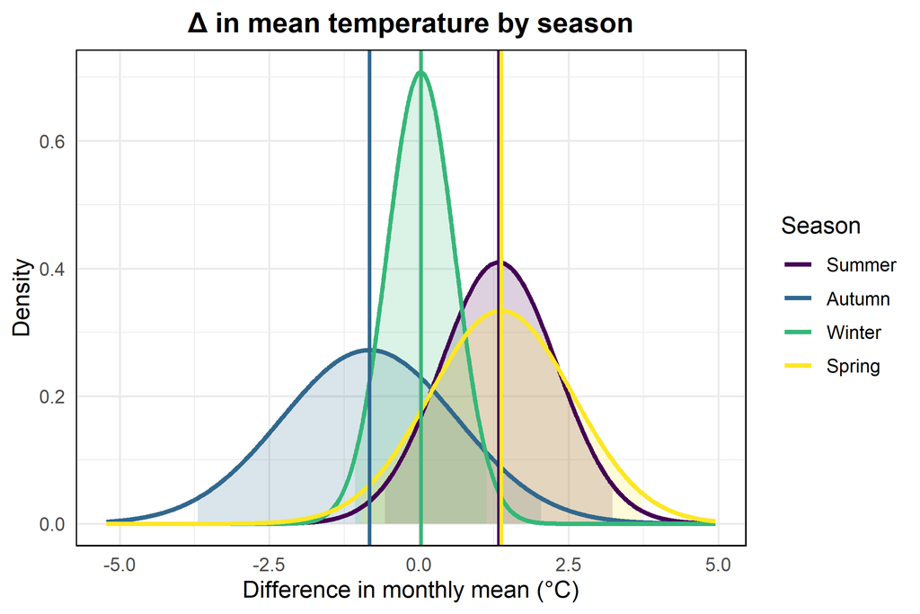

Figure 15

```r
temp_diff_stats <- temp_season_summary %>%
  select(era, season, mu, sd, n) %>%

  # Reshape so each era has its own columns
  pivot_wider(names_from = era, values_from = c(mu, sd, n)) %>%

  # Calculate mean difference and standard error of the difference
  mutate(
    dmu = `mu_2021-2024` - `mu_1991-1994`,
    se  = sqrt((`sd_1991-1994`^2 / `n_1991-1994`) +
               (`sd_2021-2024`^2 / `n_2021-2024`))
  )

# Create an x axis grid around ±3 SE of the differences
x_grid <- range(with(temp_diff_stats, c(dmu - 3*se, dmu + 3*se)), na.rm = TRUE)
x_grid <- seq(x_grid[1], x_grid[2], length.out = 1000)

# Construct a normal distribution curve for eachg season
temp_diff_norm_df <- temp_diff_stats %>%
  rowwise() %>%
  mutate(curve = list(tibble(
    x = x_grid,
    y = dnorm(x_grid, mean = dmu, sd = se),

    # mark 95% CI area
    in95 = between(x_grid, dmu - 1.96*se, dmu + 1.96*se)
  ))) %>%
  unnest(curve)

# Plot
ggplot(temp_diff_norm_df, aes(x = x, y = y, color = season)) +

  # Shaded 95% CI region for each curve
  geom_ribbon(data = filter(temp_diff_norm_df, in95),
              aes(ymin = 0, ymax = y, fill = season),
              alpha = 0.18, color = NA, show.legend = FALSE) +
  geom_line(linewidth = 1.05) +

  # Vertical lines at the mean difference
  geom_vline(data = temp_diff_norm_df, aes(xintercept = dmu, color = season),
             linewidth = 0.8, show.legend = FALSE) +
  labs(
    title = "Δ in mean temperature by season",
    x = "Difference in monthly mean (°C)", y = "Density",
    color = "Season"
  ) +
  theme_minimal(base_size = 11) +
  theme(
    panel.border = element_rect(fill = NA, linewidth = 0.6),
    plot.title = element_text(face = "bold", hjust = 0.5)
  )
```

### Exploration into Salinity as EC@25

```r
salinity_monthly_means <- monthly_means %>%

  # Keep only the salinity parameter
  filter(param_short == "Salinity") %>%
  mutate(
    month  = factor(month_num, levels = 1:12, labels = month.abb),
    season = case_when(
      month_num %in% c(12, 1, 2) ~ "Summer",
      month_num %in% c(3, 4, 5) ~ "Autumn",
      month_num %in% c(6, 7, 8) ~ "Winter",
      month_num %in% c(9, 10, 11) ~ "Spring"
    ),
    season = factor(season, levels = c("Summer","Autumn","Winter","Spring"))
  )
```

#### Distribution of Salinity (EC)

The distributions in Figure 16 for both eras are concentrated in the 110-260 μS/cm range. The 1990s show broader dispersion with a heavier right tail, whereas the 2020s are tighter and closer to a bell shaped (near normal) form, with a clear peak around ~180 μS/cm. Both eras are right skewed due to a few high EC outliers (≈370-390 μS/cm), which extend the tail without shifting the bulk of the distribution.

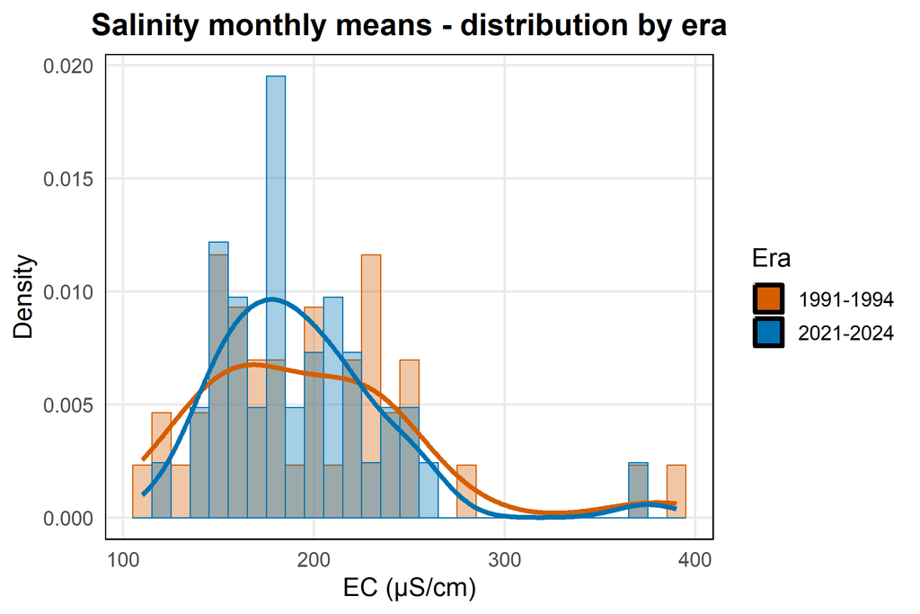

Figure 16

```r
ggplot(salinity_monthly_means, aes(x = month_mean)) +

  # Histogram of monthly means overlaid by era
  geom_histogram(
    aes(y = after_stat(density), fill = era, color = era),
    binwidth = 10, position = "identity",
    alpha = 0.35, linewidth = 0.35
  ) +

  # Density curves for each era
  geom_density(aes(color = era), linewidth = 1.1, adjust = 1.1) +

  # Hide redundant legend for line colors
  scale_color_discrete(guide = "none") +
  labs(
    title = "Salinity monthly means - distribution by era",
    x = "EC (μS/cm)", y = "Density", fill = "Era"
  ) +
  theme_minimal(base_size = 12) +
  theme(
    panel.grid.minor = element_blank(),
    panel.border = element_rect(fill = NA, linewidth = 0.6, colour = "black"),
    plot.title = element_text(face = "bold", hjust = 0.5)
  )
```

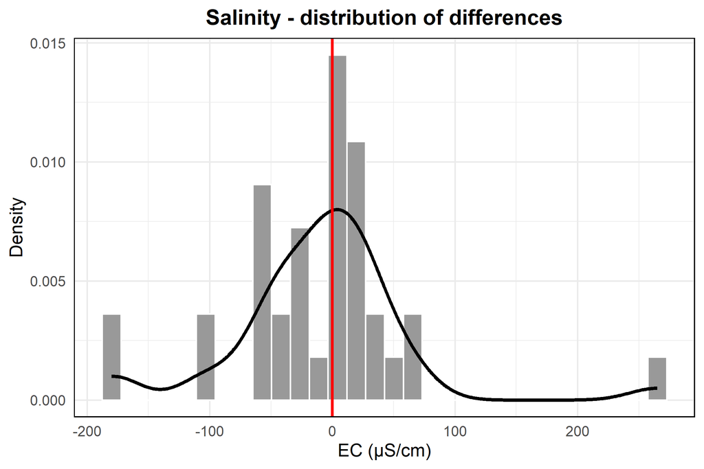

Figure 17

```r
sali_monthly_diff <- salinity_monthly_means %>%
  select(year_num, month_num, era, month_mean) %>%

  # Reshape so each era has its own column
  pivot_wider(names_from = era, values_from = month_mean) %>%

  # Calculate difference
  mutate(diff = `2021-2024` - `1991-1994`)

# Plot
ggplot(sali_monthly_diff, aes(x = diff)) +
  geom_histogram(aes(y = after_stat(density)),
                 bins = 30, color = "white", fill = "grey60") +
  geom_density(linewidth = 1, adjust = 1.1, na.rm = TRUE) +
  geom_vline(xintercept = 0, color = "red", linewidth = 0.8) +
  labs(
    title = "Salinity - distribution of differences",
    x = "EC (μS/cm)", y = "Density"
  ) +
  theme_minimal() +
  theme(panel.border = element_rect(fill = NA, linewidth = 0.6),
        plot.title = element_text(face = "bold", hjust = 0.5))
```

But if we look at the seasonal pattern, we see that across both eras the ordering is stable (Figure 18): Autumn has the highest Salinity, Spring the lowest, and Summer/Winter lie in between, with Winter typically ≥ Summer. The overall seasonal ordering is consistent between 1991-1994 and 2021-2024.

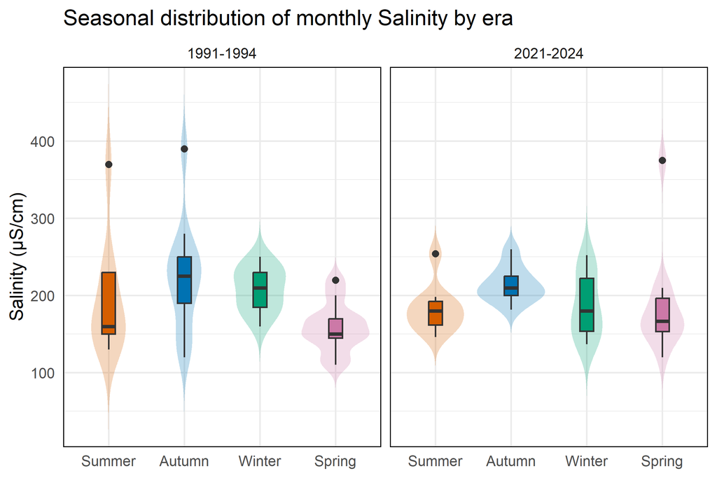

Figure 18

```r
ggplot(salinity_monthly_means,
       aes(x = season, y = month_mean, fill = season)) +

  # Violin plot shows the full seasonal distribution
  geom_violin(trim = FALSE, alpha = 0.25, color = NA) +

  # Boxplot overlay
  geom_boxplot(width = 0.18,
             outlier.shape = 16,
             outlier.size = 1.7) +
  facet_wrap(~ era) +
  labs(title = "Seasonal distribution of monthly Salinity by era",
       x = NULL,
       y = "Salinity (μS/cm)") +
  theme_minimal(base_size = 11) +
  theme(panel.border = element_rect(fill = NA),
        legend.position = "none")
```

Salinity (EC) is highly event driven, rainfall, flow pulses, evaporation, and occasional inputs can produce legitimate spikes, so outliers are expected.  
After removing seasonal (Figure 19), the seasonal pattern is unchanged: Trimming outliers mainly tightens the spread, medians and the seasonal ranking remain effectively the same, indicating the pattern is not driven by a handful of extreme months.

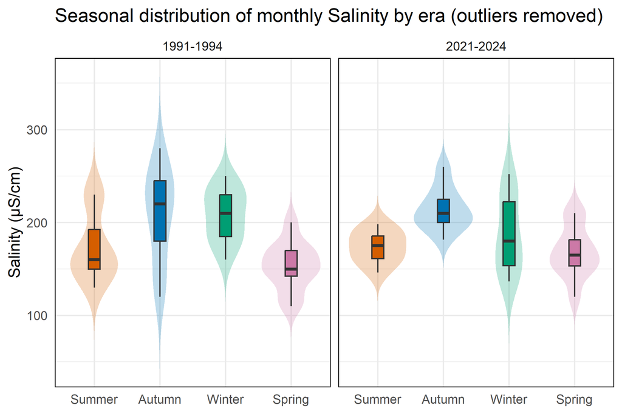

Figure 19

```r
salinity_no_outlier <- salinity_monthly_means %>%

  # Work within each era × season group
  group_by(era, season) %>%
  mutate(
    Q1 = quantile(month_mean, 0.25, na.rm = TRUE),
    Q3 = quantile(month_mean, 0.75, na.rm = TRUE),
    IQR = Q3 - Q1,
    lower = Q1 - 1.5 * IQR,
    upper = Q3 + 1.5 * IQR
  ) %>%
  ungroup() %>%

  # Keep only values within [Q1 − 1.5*IQR, Q3 + 1.5*IQR]
  filter(month_mean >= lower & month_mean <= upper)

# Plot
ggplot(salinity_no_outlier, aes(x = season, y = month_mean, fill = season)) +
  geom_violin(trim = FALSE, alpha = 0.25, color = NA) +
  geom_boxplot(width = 0.18, outlier.shape = NA) +
  facet_wrap(~ era) +
  labs(
    title = "Seasonal distribution of monthly Salinity by era (outliers removed)",
    x = NULL, y = "Salinity (μS/cm)"
  ) +
  theme_minimal(base_size = 11) +
  theme(
    panel.border = element_rect(fill = NA),
    legend.position = "none"
  )
```

#### Era Summary of Salinity Monthly Means

- Summer: Median rises (ΔMedian +20), but the upper tail drops (ΔQ3 −37.5; Δmax −116) and variability shrinks (ΔSD −43). Fewer very high EC months; overall mean slightly down.
- Autumn: Higher floor, lower ceiling (Δmin +62; Δmax −130) and smaller spread (ΔSD −48). Both center and upper tail move down (ΔMedian −15; ΔQ3 −25).
- Winter: Broad decrease at the lower tail (ΔQ1 −31.2; ΔMedian −30) with a modest increase in spread (ΔSD +13). Mean is slightly negative (Δμ −21).
- Spring: Across the board increase with lower, middle, and upper quantiles all rise (ΔQ1 +8.3; ΔMedian +17; ΔQ3 +26.7) and extremes expand (Δmax +155; ΔSD +36).

```r
sali_season_diff <- salinity_monthly_means %>%
  group_by(era, season) %>%

  # Summarise salinity stats by era × season
  summarise(
    n = n(),
    min = min(month_mean, na.rm = TRUE),
    q1 = quantile(month_mean, 0.25, na.rm = TRUE),
    med = median(month_mean, na.rm = TRUE),
    q3 = quantile(month_mean, 0.75, na.rm = TRUE),
    max = max(month_mean, na.rm = TRUE),
    mu = mean(month_mean, na.rm = TRUE),
    sd = sd(month_mean,   na.rm = TRUE),
    se = sd / sqrt(n),
    .groups = "drop"
  ) %>%
  select(season, era, min, q1, med, q3, max, mu, sd, se) %>%

   # Pivot wider so each era has its own column
  pivot_wider(
    names_from = era,
    values_from = c(min, q1, med, q3, max, mu, sd, se)
  ) %>%

  # Compute differences
  mutate(
    `Δ μ` = `mu_2021-2024` - `mu_1991-1994`,
    `Δ Median` = `med_2021-2024` - `med_1991-1994`,
    `Δ Q1` = `q1_2021-2024` - `q1_1991-1994`,
    `Δ Q3` = `q3_2021-2024` - `q3_1991-1994`,
    `Δ min` = `min_2021-2024` - `min_1991-1994`,
    `Δ max` = `max_2021-2024` - `max_1991-1994`,
    `Δ SD` = `sd_2021-2024` - `sd_1991-1994`,
    `Δ SE` = `se_2021-2024` - `se_1991-1994`
  ) %>%

  # Keep only difference columns
  transmute(season, `Δ μ`, `Δ Median`, `Δ Q1`, `Δ Q3`,
            `Δ min`, `Δ max`, `Δ SD`, `Δ SE`) %>%

  # 6. Round numeric values to 2 decimals
  mutate(across(-season, ~ round(.x, 2))) %>%
  arrange(season)

kable(
  sali_season_diff,
  caption = "Seasonal differences in salinity (2021-2024 − 1991-1994)"
)
```

Table 10: Seasonal differences in salinity (2021-2024 − 1991-1994)

| season | Δ μ | Δ Median | Δ Q1 | Δ Q3 | Δ min | Δ max | Δ SD | Δ SE |
| --- | --- | --- | --- | --- | --- | --- | --- | --- |
| Summer | -13 | 20 | 11.7 | -37.5 | 16 | -116 | -43 | -14.3 |
| Autumn | -9 | -15 | 10.0 | -25.0 | 62 | -130 | -48 | -13.2 |
| Winter | -21 | -30 | -31.2 | -7.5 | -23 | 2 | 13 | 3.8 |
| Spring | 28 | 17 | 8.3 | 26.7 | 10 | 155 | 36 | 10.8 |

Means are lower in Summer (Δμ −13 μS/cm), Autumn (−9), and Winter (−21), but higher in Spring (+28).  
In Figure 20, it’s clearer to see Summer, Autumn, and Winter curves sit mostly left of zero (lower mean EC in the 2020s), while Spring sits right of zero (higher mean EC). Vertical lines mark Δμ; shaded bands indicate the central ~95% for each season. Together, the figure confirms a spring increase alongside modest decreases in summer/autumn and a net decline in winter.

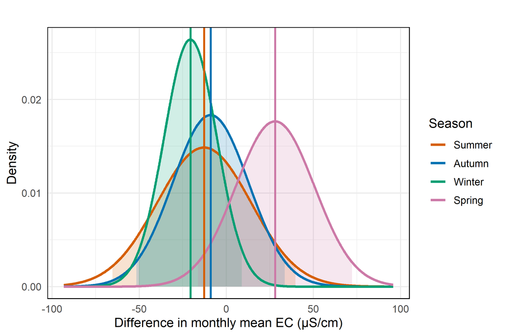

Figure 20

```r
# Summarise salinity by season and era
sali_season_summary <- salinity_monthly_means %>%
  mutate(season = factor(season, levels = c("Summer","Autumn","Winter","Spring"))) %>%
  group_by(era, season) %>%
  summarise(
    mu = mean(month_mean, na.rm = TRUE),
    sd = sd(month_mean,   na.rm = TRUE),
    n  = n(),
    .groups = "drop"
  )

# Pivot wider so each era has its own stats
sali_diff_stats <- sali_season_summary %>%
  select(era, season, mu, sd, n) %>%
  pivot_wider(names_from = era, values_from = c(mu, sd, n)) %>%

  # Calculate mean difference and standard error of the difference
  mutate(
    dmu = `mu_2021-2024` - `mu_1991-1994`,
    se  = sqrt((`sd_1991-1994`^2 / `n_1991-1994`) +
               (`sd_2021-2024`^2 / `n_2021-2024`))
  )

# Create grid of x values around ±3 SE
x_grid <- range(with(sali_diff_stats, c(dmu - 3*se, dmu + 3*se)), na.rm = TRUE)
x_grid <- seq(x_grid[1], x_grid[2], length.out = 1000)

# For each season, generate a normal curve
sali_diff_norm_df <- sali_diff_stats %>%
  rowwise() %>%
  mutate(curve = list(tibble(
    x = x_grid,
    y = dnorm(x_grid, mean = dmu, sd = se),
    in95 = between(x_grid, dmu - 1.96*se, dmu + 1.96*se)
  ))) %>%
  unnest(curve)

# Plot
ggplot(sali_diff_norm_df, aes(x = x, y = y, color = season)) +

  # Shade the 95% CI area
  geom_ribbon(data = filter(sali_diff_norm_df, in95),
              aes(ymin = 0, ymax = y, fill = season),
              alpha = 0.18, color = NA, show.legend = FALSE) +

  # Normal curve for each season
  geom_line(linewidth = 1.05) +

  # Vertical line at mean difference
  geom_vline(data = sali_diff_stats, aes(xintercept = dmu, color = season),
             linewidth = 0.8, show.legend = FALSE) +
  labs(
    title = "Δ mean salinity by season (2021-2024 − 1991-1994)",
    x = "Difference in monthly mean EC (μS/cm)", y = "Density",
    color = "Season"
  ) +
  theme_minimal(base_size = 11) +
  theme(
    panel.border = element_rect(fill = NA, linewidth = 0.6),
    plot.title = element_text(face = "bold", hjust = 0.5)
  )
```

### Exploration into Turbidity

We log transform turbidity because its values are positive and strongly right skewed logging stabilizes variance, down weights spike events, and makes differences interpretable as relative (percent) changes.

```r
turbidity_monthly_means <- monthly_means %>%

  # Keep only the turbidity
  filter(param_short == "Turbidity") %>%

  # log transform the monthly mean
  mutate(
    log_month_mean = log(month_mean)
  )
```

#### Distribution of Turbidity (NTU)

On the log scale (log(Turbidity))in Figure 21, both eras remain right skewed, and there’s a persistent upper tail of high turbidity months. The 2021-2024 distribution is tighter and more concentrated (taller peak), whereas 1991-1994 is broader with a heavier right tail, indicating more variability and more frequent high events. This pattern mirrors salinity.

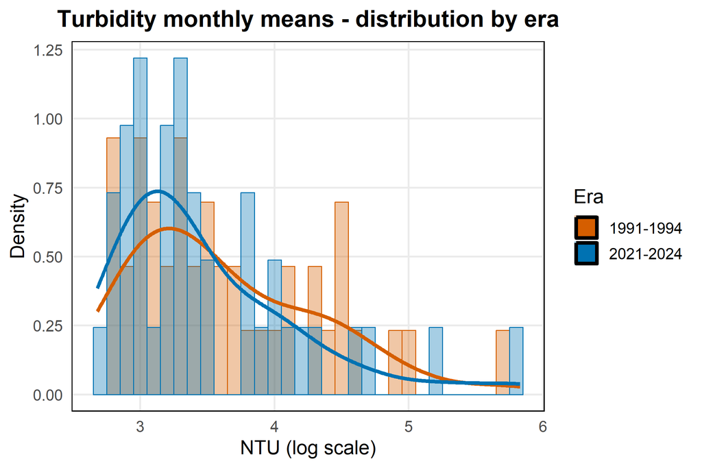

Figure 21

```r
ggplot(turbidity_monthly_means, aes(x = log_month_mean)) +

  # Histogram of log transformed turbidity overlaid by era
  geom_histogram(
    aes(y = after_stat(density), fill = era, color = era),
    binwidth = 0.1, position = "identity",
    alpha = 0.35, linewidth = 0.35
  ) +

  # Smoothed density curves for each era
  geom_density(aes(color = era), linewidth = 1.1, adjust = 1.1) +

  # Hide redundant color legend
  scale_color_discrete(guide = "none") +
  labs(
    title = "Turbidity monthly means - distribution by era",
    x = "NTU (log scale)", y = "Density", fill = "Era"
  ) +
  theme_minimal(base_size = 12) +
  theme(
    panel.grid.minor = element_blank(),
    panel.border = element_rect(fill = NA, linewidth = 0.6, colour = "black"),
    plot.title = element_text(face = "bold", hjust = 0.5)
  )
```

Figure 22 shows that the era to era difference in log turbidity is roughly bell shaped and symmetric about zero. This pattern suggests no systematic shift in turbidity between the 1990s and the 2020s.

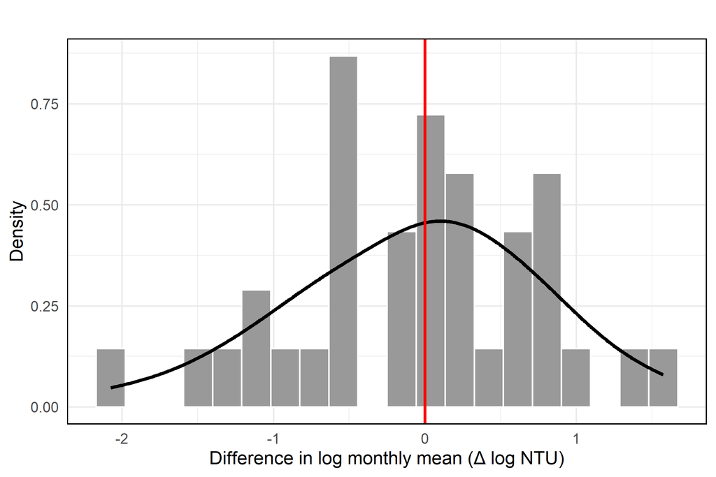

Figure 22

```r
tur_monthly_diff <- turbidity_monthly_means %>%
  select(year_num, month_num, era, log_month_mean) %>%

  # Reshape so each era has its own column
  pivot_wider(names_from = era, values_from = log_month_mean) %>%

  # Calculate difference
  mutate(diff_log = `2021-2024` - `1991-1994`)

# Plot
ggplot(tur_monthly_diff, aes(x = diff_log)) +
  geom_histogram(aes(y = after_stat(density)),
                 bins = 20, color = "white", fill = "grey60") +
  geom_density(linewidth = 1, adjust = 1.1, na.rm = TRUE) +
  geom_vline(xintercept = 0, color = "red", linewidth = 0.8) +
  labs(
    title = "Turbidity - distribution of differences (2020s − 1990s)",
    x = "Difference in log monthly mean (Δ log NTU)", y = "Density"
  ) +
  theme_minimal() +
  theme(panel.border = element_rect(fill = NA, linewidth = 0.6),
        plot.title = element_text(face = "bold", hjust = 0.5))
```

#### Era Summary of Turbidity Monthly Means

Because turbidity shows no consistent seasonal signal, it’s driven we compare era level differences directly, contrasting the overall (log-scale) distributions between 1991-1994 and 2021-2024 rather than breaking by season).  
Turbidity shows little to no era effect:

```r
tur_era_summary <- turbidity_monthly_means %>%

  # Summarise
  select(era, log_month_mean) %>%
  group_by(era) %>%
  summarise(
    n = n(),
    min = min(log_month_mean, na.rm = TRUE),
    q1 = quantile(log_month_mean, 0.25, na.rm = TRUE),
    med = median(log_month_mean, na.rm = TRUE),
    q3 = quantile(log_month_mean, 0.75, na.rm = TRUE),
    max = max(log_month_mean, na.rm = TRUE),
    mu = mean(log_month_mean, na.rm = TRUE),
    sd = sd(log_month_mean,   na.rm = TRUE),
    se = sd / sqrt(n),
    t95 = qt(0.975, df = n - 1),
    ci_low = mu - t95 * se,
    ci_high = mu + t95 * se,
    .groups = "drop"
  ) %>%

  # Format results for clearer reporting
  mutate(
    Range = sprintf("%.2f–%.2f", min, max),
    `Median (Q1, Q3)` = sprintf("%.2f<br>(%.2f, %.2f)", med, q1, q3),
    `95% CI for μ` = sprintf("%.2f–%.2f", ci_low, ci_high)
  ) %>%
  select(
    era, n, Range, min, q1, med, q3, max,
    mu, sd, se, `95% CI for μ`, `Median (Q1, Q3)`
  )

kable(tur_era_summary,
      caption = "Turbidity Monthly Means (log) - Era Summary")
```

Table 11: Turbidity Monthly Means (log) - Era Summary

| era | n | Range | min | q1 | med | q3 | max | mu | sd | se | 95% CI for μ | Median (Q1, Q3) |
| --- | --- | --- | --- | --- | --- | --- | --- | --- | --- | --- | --- | --- |
| 1991-1994 | 43 | 2.77–5.70 | 2.8 | 3.1 | 3.5 | 4.1 | 5.7 | 3.6 | 0.69 | 0.11 | 3.42–3.85 | 3.47 (3.09, 4.08) |
| 2021-2024 | 41 | 2.68–5.83 | 2.7 | 3.0 | 3.3 | 3.8 | 5.8 | 3.5 | 0.69 | 0.11 | 3.27–3.71 | 3.28 (3.00, 3.81) |

Figure 23 shows a standard-deviation visualization (normal curves with μ and ±1 SD marked).  
The overlaid curves and μ markers nearly coincide, any variability appears even driven rather than a shift in central tendency.

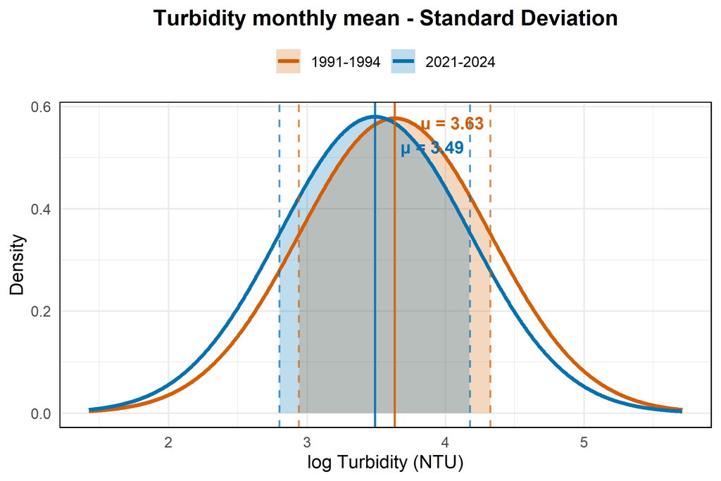

Figure 23

```r
turbidity_stats <- turbidity_monthly_means %>%

  # Summarise mean and SD of log turbidity for each era
  group_by(era) %>%
  summarise(mu = mean(log_month_mean, na.rm = TRUE),
            sd = sd(log_month_mean,   na.rm = TRUE),
            .groups = "drop")

# Define plotting grid around ±3 SD of the means
x_min <- min(turbidity_stats$mu - 3*turbidity_stats$sd)
x_max <- max(turbidity_stats$mu + 3*turbidity_stats$sd)
grid  <- seq(x_min, x_max, length.out = 1000)

# Construct normal curves for each era
tur_norm_df <- turbidity_stats %>%
  rowwise() %>%
  mutate(curve = list(tibble(
    x = grid,
    y = dnorm(grid, mean = mu, sd = sd),
    in_1sd = abs(grid - mu) <= sd
  ))) %>%
  unnest(curve)

# Add labels for mean values
tur_stats_lab <- turbidity_stats %>%
  mutate(
    y_lab = dnorm(mu, mean = mu, sd = sd) * 0.92,
    label = sprintf("μ = %.2f", mu),
    vjust_shift = if_else(era == "1991-1994", -1, 1)
  )

# Plot
ggplot(tur_norm_df, aes(x = x, y = y, color = era)) +

  # Shaded ±1 SD region
  geom_ribbon(
    data = subset(tur_norm_df, in_1sd),
    aes(x = x, ymin = 0, ymax = y, fill = era),
    alpha = 0.25, color = NA, inherit.aes = FALSE
  ) +

  # Density curves
  geom_line(linewidth = 1.1) +

  # Vertical lines
  geom_vline(data = turbidity_stats, aes(xintercept = mu,  color = era),
             linetype = "solid",  linewidth = 0.7, alpha = 0.9, show.legend = FALSE) +
  geom_vline(data = turbidity_stats, aes(xintercept = mu - sd, color = era),
             linetype = "dashed", linewidth = 0.6, alpha = 0.7, show.legend = FALSE) +
  geom_vline(data = turbidity_stats, aes(xintercept = mu + sd, color = era),
             linetype = "dashed", linewidth = 0.6, alpha = 0.7, show.legend = FALSE) +

  # Mean labels
  geom_text(  data = tur_stats_lab,
  aes(x = mu, y = y_lab, label = label, color = era, hjust = -0.4, vjust = vjust_shift),
  fontface = "bold", size = 3.6,
  show.legend = FALSE
) +
  labs(
    title = "Turbidity monthly mean - Standard Deviation",
    x = "log Turbidity (NTU)", y = "Density", color = NULL, fill = NULL
  ) +
  theme_minimal(base_size = 11) +
  theme(
    legend.position = "top",
    panel.border = element_rect(fill = NA, linewidth = 0.6),
    plot.title = element_text(face = "bold", hjust = 0.5)
  )
```

### The relationship between variables

Table 12 and Figure 24 summarise pairwise relationships among the four core parameters using monthly means. In 1991-1994, most correlations are close to zero, and the scatter panels in Figure 24 show diffuse point clouds with no clear linear slope, indicating weak co-variation among pH, temperature, turbidity and salinity. In contrast, the 2021-2024 panels show stronger structure for selected pairs. Most notably, salinity and turbidity show a moderate positive association in the 2020s (r ≈ 0.57): the 2021-2024 points form a clearer upward trend, whereas the 1991-1994 points suggest a weaker and slightly negative pattern (r ≈ −0.30), implying a possible shift in how these two parameters co-vary across eras. The figure also supports a weak-to-moderate negative relationship between pH and temperature in the 2020s (r ≈ −0.34), with a slight downward tilt in the recent-era scatter that is not apparent in the early period. The diagonal density panels show substantial overlap in marginal distributions across eras, suggesting that the key difference lies more in co-movement patterns than in complete distributional separation. However, because these results are based on monthly means, the observed relationships may partly reflect shared seasonal structure and uneven sampling across months, so they should be interpreted as descriptive rather than causal evidence.

```r
# Prepare wide monthly-mean table
wq_monthly_wide <- monthly_means %>%
  select(era, year_num, month_num, param_short, month_mean) %>%
  pivot_wider(names_from = param_short, values_from = month_mean)

# Quick correlation by era
wq_monthly_wide %>%
  group_by(era) %>%
  summarise(
    cor_temp_sal = cor(Temperature, Salinity, use = "complete.obs"),
    cor_temp_turb = cor(Temperature, Turbidity, use = "complete.obs"),
    cor_sal_turb = cor(Salinity, Turbidity, use = "complete.obs"),
    cor_ph_temp = cor(pH, Temperature, use = "complete.obs"),
    .groups = "drop") %>%
  kable()
```

Table 12

| era | cor_temp_sal | cor_temp_turb | cor_sal_turb | cor_ph_temp |
| --- | --- | --- | --- | --- |
| 1991-1994 | 0.09 | 0.05 | -0.30 | 0.05 |
| 2021-2024 | -0.08 | -0.15 | 0.57 | -0.34 |

```r
# Create shared data for linked highlighting
wq_key <- highlight_key(
  wq_monthly_wide,
  ~ paste(era, year_num, month_num, sep = "_")
)

# Pairs plot
relationship_plot <- ggpairs(
  wq_key,
  columns = c("pH", "Temperature", "Turbidity", "Salinity"),
  aes(color = era, alpha = 0.7)
)

ggplotly(relationship_plot) %>%
  highlight("plotly_selected")
```

[interactive chart not shown]

Figure 24

### Summary for Question

*Has water quality declined from the 1990s to recent years?*

**No clear decline**. At Yarra River @ Chandler Highway, Kew (37°47′09.2″ S, 145°01′30.2″ E; Melbourne Water CMA), we compared 1991–1994 with 2021–2024. Over 30 years of catchment development and a warmer climate, the basic water quality signals look mixed or stable rather than getting worse overall.

According to the [Victorian Water Quality Analysis 2022 Summary Report - Department of Environment, Land, Water and Planning, 2022](https://www.water.vic.gov.au/__data/assets/pdf_file/0036/685890/Victorian-water-quality-analysis-2022-summary-report.pdf), lower salinity and turbidity generally indicate improvements in water quality. For this site, however, we do not see a straightforward decline in water quality from the early 1990s to the present.

Overall, the results suggest mixed changes rather than a simple decline; there is no clear evidence of deterioration in water quality at this site.

## Question 3

### Lineup for ΔpH (2020s − 1990s)

Based on Figure 12, we expect the distribution of monthly pH differences to be approximately normally distributed. Under *H*$_0$, we therefore generate the null panels from a Normal distribution with mean 0 and standard deviation equal to the observed SD of the differences.  
Panel 4 stands out. Most of its mass lies to the right of 0, while the null panels are symmetric around 0. This is visual evidence against the null and is consistent with higher pH in 2021–2024.

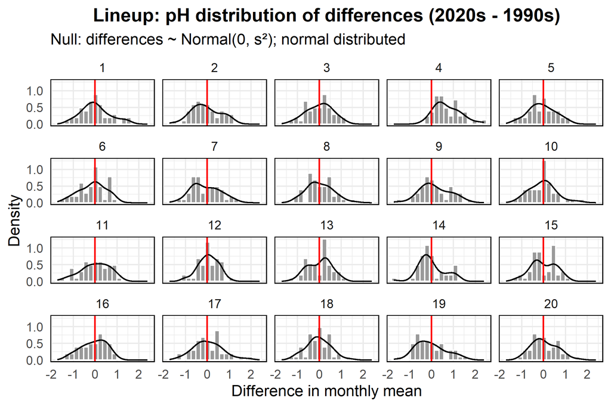

Figure 25

```r
set.seed(35717343)

# Calculate observed SD of pH differences
ph_sd_obs <- sd(ph_monthly_means_diff$diff, na.rm = TRUE)

# Generate a lineup of 20 datasets
ph_lineup <- lineup(
  null_dist("diff", "norm", params = list(mean = 0, sd = ph_sd_obs)),
  ph_monthly_means_diff %>% select(diff),
  n = 20
)

# Plot
ggplot(ph_lineup, aes(x = diff)) +
  geom_histogram(aes(y = after_stat(density)),
                 bins = 20, color = "white", fill = "grey60") +
  geom_density(linewidth = 0.5, adjust = 1.1) +
  geom_vline(xintercept = 0, color = "red", linewidth = 0.6) +
  facet_wrap(~ .sample, ncol = 5) +
  labs(
    title = "Lineup: pH distribution of differences (2020s - 1990s)",
    subtitle = "Null: differences ~ Normal(0, s²); normal distributed",
    x = "Difference in monthly mean", y = "Density"
  ) +
  theme_minimal() +
  theme(panel.border = element_rect(fill = NA, linewidth = 0.6),
        plot.title = element_text(face = "bold", hjust = 0.5))
```

### Lineup for ΔTemperature (2020s − 1990s)

Based on Figure 14, we model the month-by-month temperature differences as approximately Normal. Under H0, we generate the null panels from Normal(0, s²), with s set to the observed SD of the differences across months.  
Panel 5 stands out. It shows positive anomalies in summer/spring, negative in autumn, and near zero in winter, while the null panels look like random scatter around 0. This is visual evidence against the null and is consistent with a seasonal warming signal.

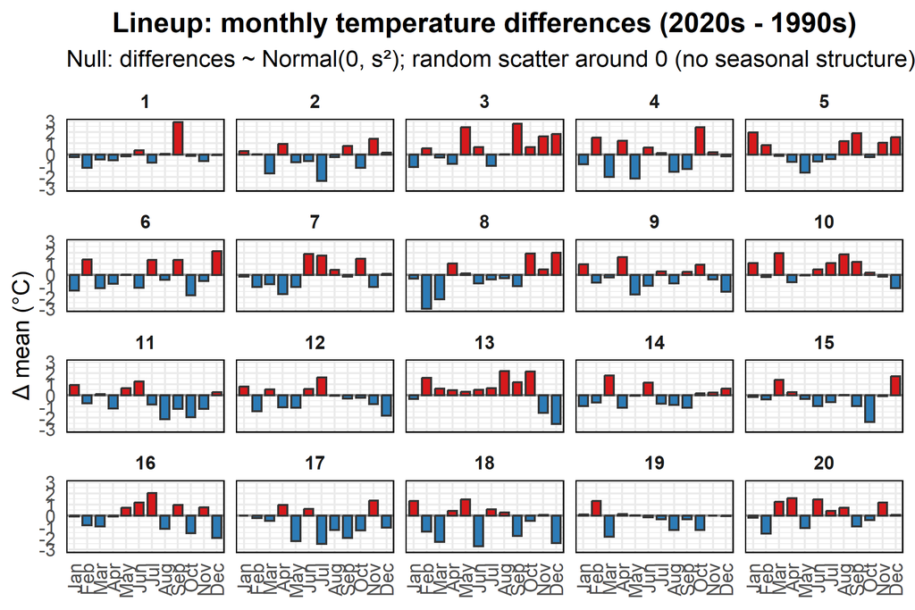

Figure 26

```r
set.seed(35717343)

# Calculate observed SD of temperature differences
sd_obs <- sd(temp_bar_diff_season$diff, na.rm = TRUE)

# Generate a lineup of 20 datasets
temp_lineup <- lineup(
  null_dist("diff", "norm", params = list(mean = 0, sd = sd_obs)),
  temp_bar_diff_season,
  n = 20
)

# Plot
ggplot(temp_lineup, aes(x = month, y = diff, fill = diff > 0)) +
  geom_hline(yintercept = 0, color = "grey60", linewidth = 0.6) +
  geom_col(width = 0.7, color = "grey20", show.legend = FALSE) +
  scale_fill_manual(values = c(`TRUE` = "#D7191C", `FALSE` = "#2C7BB6")) +
  facet_wrap(~ .sample, ncol = 5) +
  labs(
  title = "Lineup: monthly temperature differences (2020s - 1990s)",
  subtitle = "Null: differences ~ Normal(0, s²); random scatter around 0 (no seasonal structure)",
    x = NULL, y = "Δ mean (°C)"
  ) +
  theme_minimal(base_size = 11) +
  theme(
    panel.border = element_rect(fill = NA, linewidth = 0.6),
    strip.text = element_text(face = "bold"),
    plot.title = element_text(face = "bold", hjust = 0.5),
    axis.text.x = element_text(angle = 90, vjust = 0.5, hjust = 1)
  )
```

### Lineup for ΔSalinity (2020s − 1990s)

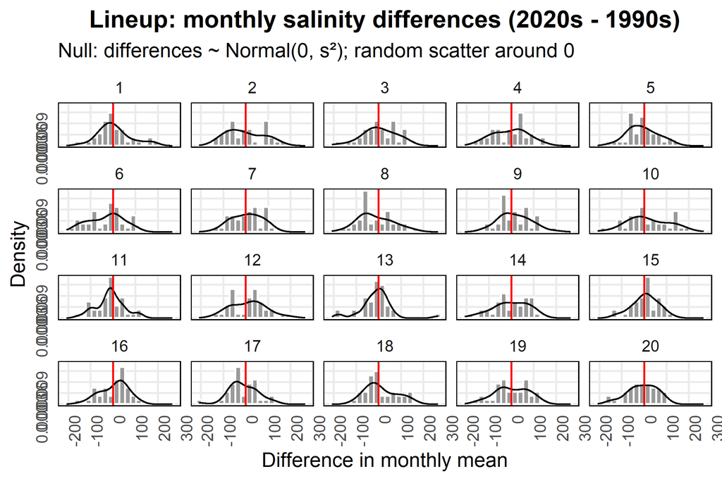

Figure 27

```r
set.seed(35717343)

# Calculate observed SD of salinity differences
sd_obs <- sd(sali_monthly_diff$diff, na.rm = TRUE)

# Generate a lineup of 20 datasets
sal_lineup <- lineup(
  null_dist("diff", "norm", params = list(mean = 0, sd = sd_obs)),
  sali_monthly_diff %>% select(diff) %>% drop_na(),
  n = 20
)

# Plot
ggplot(sal_lineup, aes(x = diff)) +
  geom_histogram(aes(y = after_stat(density)),
                 bins = 20, color = "white", fill = "grey60") +
  geom_density(linewidth = 0.5, adjust = 1.1) +
  geom_vline(xintercept = 0, color = "red", linewidth = 0.6) +
  facet_wrap(~ .sample, ncol = 5) +
  labs(
  title = "Lineup: monthly salinity differences (2020s - 1990s)",
  subtitle = "Null: differences ~ Normal(0, s²); random scatter around 0",
    x = "Difference in monthly mean", y = "Density"
  ) +
  theme_minimal(base_size = 12) +
  theme(
    panel.border = element_rect(fill = NA, linewidth = 0.6, colour = "black"),
    panel.grid.minor = element_blank(),
    plot.title = element_text(face = "bold", hjust = 0.5),
    axis.text = element_text(angle = 90, vjust = 0.5, hjust = 1)
  )
```

Results:

- pH: Panel 4 is clearly shifted right of 0 → reject *H*$_0$
- Temperature: Panel 5 shows positives in summer/spring, negatives in autumn, ~0 in winter → reject *H*$_0$
- Salinity (EC): Panel 13 is tightly centered near 0 with heavier tails/visible outlier → reject *H*$_0$

## Generative AI analysis

I used [ChatGPT](https://chatgpt.com/share/68b2f464-7e9c-8009-9dbb-9d83c2a08b61) to help with parts of my R code. It gave me suggestions for how to make the code shorter. These were correct, but they were not functions we had really practiced, so I usually rewrote the code in a more basic way. This made it easier for me to understand and also more consistent with my course.

ChatGPT often gave me a lot of information, but many times the information was either wrong or misleading. I had to double check with other references to make sure it was correct. Even so, it was still useful as an early idea generator, because it helped me to get an overall understanding of the task. I also noticed that it sometimes provided random links or PDFs that were fake or unreliable, so I learned not to trust those parts.

Overall, ChatGPT was helpful for brainstorming and checking syntax, but I had to think carefully, test everything, and rewrite it in my own way so it matched my understanding and the level of the unit.

I also asked Notion AI to fix my grammar errors. (Because sometimes GPT will change my words when I just want to fix the grammar)

## Limitations

- Data quality isn’t the same across eras. In 1991–1994 a lot of records are code 65 (supplied by others; not validated), but in 2021–2024 they’re code 2 (good). So part of the difference could be data handling, not the river.
- Big time gap. There’s no quality data from 1995–2019, and I only used four years per era (dropping 2020 and 2025 because they had <6 months). That makes it hard to see long, slow trends.
- Uneven sampling. The 1990s are basically one sample per month; the 2020s have some months with many samples and some with none. I used monthly means to smooth this, but the imbalance can still affect variability.
- One site. Everything is from Yarra @ Chandler Hwy. Results might not generalise upstream or downstream.
- Methods may have changed. Instruments, lab methods, detection limits, or EC temperature correction could differ between eras. I didn’t audit that, so step changes might be methodological.
- Event bias. Turbidity and salinity spike with storms/low flows. If sampling didn’t hit the same kinds of events in both eras, comparisons can be skewed.
- Missing data and choices. Some months are missing (probably not at random). Some choices can nudge results.

## References

Department of Energy, Environment and Climate Action (DEECA). (n.d.-a). Water quality parameters. State Government of Victoria. Retrieved August 30, 2025, from https://data.water.vic.gov.au/water-quality-parameters

Department of Energy, Environment and Climate Action (DEECA). (n.d.-b). What do quality codes mean? State Government of Victoria. Retrieved August 30, 2025, from https://data.water.vic.gov.au/what-do-quality-codes-mean

The Water Unit Project. (n.d.). Yarra River Report. Retrieved August 30, 2025, from https://thewaterunitproject.wordpress.com/yarra-river-report/

Department of Environment, Land, Water and Planning. (2022). Victorian water quality analysis 2022: Summary report. State Government of Victoria. https://www.water.vic.gov.au/__data/assets/pdf_file/0036/685890/Victorian-water-quality-analysis-2022-summary-report.pdf

## Citations

Buja A, Cook D, Hofmann H, Lawrence M, Lee E, Swayne DF, Wickham H (2009). “Statistical Inference for Exploratory Data Analysis and Model Diagnostics.” *Royal Society Philosophical Transactions A*, *367*(1906), 4361-4383. doi:10.1098/rsta.2009.0120 https://doi.org/10.1098/rsta.2009.0120.

Wickham H, Averick M, Bryan J, Chang W, McGowan LD, François R, Grolemund G, Hayes A, Henry L, Hester J, Kuhn M, Pedersen TL, Miller E, Bache SM, Müller K, Ooms J, Robinson D, Seidel DP, Spinu V, Takahashi K, Vaughan D, Wilke C, Woo K, Yutani H (2019). “Welcome to the tidyverse.” *Journal of Open Source Software*, *4*(43), 1686. doi:10.21105/joss.01686 https://doi.org/10.21105/joss.01686.

Wickham H, Bryan J (2025). *readxl: Read Excel Files*. R package version 1.4.4, https://CRAN.R-project.org/package=readxl.

Wickham H, Pedersen T, Seidel D (2025). *scales: Scale Functions for Visualization*. R package version 1.4.0, https://CRAN.R-project.org/package=scales

Xie Y (2025). *knitr: A General-Purpose Package for Dynamic Report Generation in R*. R package version 1.50, https://yihui.org/knitr/

Tierney N (2017). “visdat: Visualising Whole Data Frames.” *JOSS*, *2*(16), 355. doi:10.21105/joss.00355 https://doi.org/10.21105/joss.00355, http://dx.doi.org/10.21105/joss.00355

Zhu H (2024). *kableExtra: Construct Complex Table with ‘kable’ and Pipe Syntax*. R package version 1.4.0, https://CRAN.R-project.org/package=kableExtra.

Xie Y, Cheng J, Tan X (2024). *DT: A Wrapper of the JavaScript Library ‘DataTables’*. R package version 0.33, https://CRAN.R-project.org/package=DT.

C. Sievert. Interactive Web-Based Data Visualization with R, plotly, and shiny. Chapman and Hall/CRC Florida, 2020.

Schloerke B, Cook D, Larmarange J, Briatte F, Marbach M, Thoen E, Elberg A, Crowley J (2025). *GGally: Extension to ‘ggplot2’*. doi:10.32614/CRAN.package.GGally https://doi.org/10.32614/CRAN.package.GGally, R package version 2.4.0, https://CRAN.R-project.org/package=GGally.